# Created by Benjamin Fundelits

## Gather

### Local Disk

```python
import pandas as pd
import numpy as np
import requests
import csv
import tweepy
import json
import matplotlib.pyplot as plt
import re
```

```python
# Import archive data
archive = pd.read_csv("twitter-archive-enhanced.csv")
```

```python
# Check to see if the file was imported correctly
archive.head()
```

|  | tweet_id | in_reply_to_status_id | in_reply_to_user_id | timestamp | source | text | retweeted_status_id | retweeted_status_user_id | retweeted_status_timestamp | expanded_urls | rating_numerator | rating_denominator | name | doggo | floofer | pupper | puppo |
| --- | --- | --- | --- | --- | --- | --- | --- | --- | --- | --- | --- | --- | --- | --- | --- | --- | --- |
| 0 | 892420643555336193 | NaN | NaN | 2017-08-01 16:23:56 +0000 | <a href="http://twitter.com/download/iphone" r... | This is Phineas. He's a mystical boy. Only eve... | NaN | NaN | NaN | https://twitter.com/dog_rates/status/892420643... | 13 | 10 | Phineas | None | None | None | None |
| 1 | 892177421306343426 | NaN | NaN | 2017-08-01 00:17:27 +0000 | <a href="http://twitter.com/download/iphone" r... | This is Tilly. She's just checking pup on you.... | NaN | NaN | NaN | https://twitter.com/dog_rates/status/892177421... | 13 | 10 | Tilly | None | None | None | None |
| 2 | 891815181378084864 | NaN | NaN | 2017-07-31 00:18:03 +0000 | <a href="http://twitter.com/download/iphone" r... | This is Archie. He is a rare Norwegian Pouncin... | NaN | NaN | NaN | https://twitter.com/dog_rates/status/891815181... | 12 | 10 | Archie | None | None | None | None |
| 3 | 891689557279858688 | NaN | NaN | 2017-07-30 15:58:51 +0000 | <a href="http://twitter.com/download/iphone" r... | This is Darla. She commenced a snooze mid meal... | NaN | NaN | NaN | https://twitter.com/dog_rates/status/891689557... | 13 | 10 | Darla | None | None | None | None |
| 4 | 891327558926688256 | NaN | NaN | 2017-07-29 16:00:24 +0000 | <a href="http://twitter.com/download/iphone" r... | This is Franklin. He would like you to stop ca... | NaN | NaN | NaN | https://twitter.com/dog_rates/status/891327558... | 12 | 10 | Franklin | None | None | None | None |

### Udacity Website

```python
# Import image predictions
url = "https://d17h27t6h515a5.cloudfront.net/topher/2017/August/599fd2ad_image-predictions/image-predictions.tsv"

with requests.Session() as s:
    download = s.get(url)

    decoded_content = download.content.decode("utf-8")

    reader = csv.reader(decoded_content.splitlines(), delimiter = '\t')

    downloaded_ip_list = list(reader)
```

```python
# Convert downloaded csv into a dataframe
image_prediction = pd.DataFrame(data = downloaded_ip_list[1:], columns = downloaded_ip_list[0])
```

```python
# Check to see if file was imported correctly
image_prediction.head(10)
```

|  | tweet_id | jpg_url | img_num | p1 | p1_conf | p1_dog | p2 | p2_conf | p2_dog | p3 | p3_conf | p3_dog |
| --- | --- | --- | --- | --- | --- | --- | --- | --- | --- | --- | --- | --- |
| 0 | 666020888022790149 | https://pbs.twimg.com/media/CT4udn0WwAA0aMy.jpg | 1 | Welsh_springer_spaniel | 0.465074 | True | collie | 0.156665 | True | Shetland_sheepdog | 0.0614285 | True |
| 1 | 666029285002620928 | https://pbs.twimg.com/media/CT42GRgUYAA5iDo.jpg | 1 | redbone | 0.506826 | True | miniature_pinscher | 0.07419169999999999 | True | Rhodesian_ridgeback | 0.07201 | True |
| 2 | 666033412701032449 | https://pbs.twimg.com/media/CT4521TWwAEvMyu.jpg | 1 | German_shepherd | 0.596461 | True | malinois | 0.13858399999999998 | True | bloodhound | 0.11619700000000001 | True |
| 3 | 666044226329800704 | https://pbs.twimg.com/media/CT5Dr8HUEAA-lEu.jpg | 1 | Rhodesian_ridgeback | 0.408143 | True | redbone | 0.360687 | True | miniature_pinscher | 0.222752 | True |
| 4 | 666049248165822465 | https://pbs.twimg.com/media/CT5IQmsXIAAKY4A.jpg | 1 | miniature_pinscher | 0.560311 | True | Rottweiler | 0.243682 | True | Doberman | 0.154629 | True |
| 5 | 666050758794694657 | https://pbs.twimg.com/media/CT5Jof1WUAEuVxN.jpg | 1 | Bernese_mountain_dog | 0.651137 | True | English_springer | 0.263788 | True | Greater_Swiss_Mountain_dog | 0.0161992 | True |
| 6 | 666051853826850816 | https://pbs.twimg.com/media/CT5KoJ1WoAAJash.jpg | 1 | box_turtle | 0.9330120000000001 | False | mud_turtle | 0.04588540000000001 | False | terrapin | 0.017885299999999996 | False |
| 7 | 666055525042405380 | https://pbs.twimg.com/media/CT5N9tpXIAAifs1.jpg | 1 | chow | 0.692517 | True | Tibetan_mastiff | 0.058279399999999995 | True | fur_coat | 0.0544486 | False |
| 8 | 666057090499244032 | https://pbs.twimg.com/media/CT5PY90WoAAQGLo.jpg | 1 | shopping_cart | 0.962465 | False | shopping_basket | 0.014593799999999999 | False | golden_retriever | 0.00795896 | True |
| 9 | 666058600524156928 | https://pbs.twimg.com/media/CT5Qw94XAAA_2dP.jpg | 1 | miniature_poodle | 0.201493 | True | komondor | 0.192305 | True | soft-coated_wheaten_terrier | 0.08208610000000001 | True |

### API

```python
# text file name
text_file_name = "tweet_json.txt"
```

##### Load Data from API

If you do not want to load all data from the API again, check down below the "Load Data from Text" title

```python
#Hide this code part
#My authentication informations
my_secret_consumer_key = "Private_information"
my_secret_consumer_secret = "Private_information"
my_secret_access_token = "Private_information"
my_secret_access_token_secret = "Private_information"
```

```python
# Authentication
auth = tweepy.OAuthHandler(consumer_key = my_secret_consumer_key,
                           consumer_secret = my_secret_consumer_secret)
auth.set_access_token(my_secret_access_token, my_secret_access_token_secret)
```

```python
# Get Tweepy API
api = tweepy.API(auth, wait_on_rate_limit = True, wait_on_rate_limit_notify = True)
```

```python
# Gather json tweets into a list
counter = 0
tweet_json_list_from_api = []
for _id in archive['tweet_id']:
    try:
        tweet = api.get_status(_id)
        tweet_json_list.append(tweet._json)
    except:
        continue
```

```python
# Write tweet json objects into a text
with open(text_file_name, "a", encoding="utf-8") as text_file:
    for tweet in tweet_json_list_from_api:
        json.dump(tweet, text_file)
        text_file.write("\n")
```

#### Load Data from Text

Load json from text, if we shutted down the Kernel. In this case we do not have to load all data from the API again

```python
# Load json from text
tweet_json_list = []
with open(text_file_name, "r", encoding = 'utf-8') as text_file:
    for line in text_file:
        tweet_line = line
        tweet_json_list.append(tweet_line)
```

```python
# Gather important informations from tweets into a list of dictionaries
tweet_list = []

for token in tweet_json_list:
    tweet = json.loads(token)
    tweet_id = tweet["id_str"]
    retweet_count = tweet["retweet_count"]
    favorite_count = tweet["favorite_count"]

    tweet_list.append({
        "id" : tweet_id,
        "retweet_count" : retweet_count,
        "favorite_count" : favorite_count,
    })
```

```python
# Create Data Frame from list of dictionaries
tweet_count = pd.DataFrame(tweet_list, columns = ["id", "retweet_count",  "favorite_count"])
```

```python
# Check to see if counts were gathered correctly
tweet_count.sample(10)
```

|  | id | retweet_count | favorite_count |
| --- | --- | --- | --- |
| 420 | 821107785811234820 | 2405 | 10463 |
| 434 | 819347104292290561 | 1354 | 7871 |
| 1410 | 698195409219559425 | 6586 | 18053 |
| 1638 | 683742671509258241 | 3690 | 7023 |
| 1867 | 675047298674663426 | 356 | 1118 |
| 574 | 800141422401830912 | 2909 | 16797 |
| 55 | 881536004380872706 | 16212 | 49668 |
| 712 | 783085703974514689 | 2501 | 8934 |
| 965 | 750026558547456000 | 873 | 2936 |
| 1124 | 728409960103686147 | 2217 | 5284 |

## Assess

```python
archive.head()
```

|  | tweet_id | in_reply_to_status_id | in_reply_to_user_id | timestamp | source | text | retweeted_status_id | retweeted_status_user_id | retweeted_status_timestamp | expanded_urls | rating_numerator | rating_denominator | name | doggo | floofer | pupper | puppo |
| --- | --- | --- | --- | --- | --- | --- | --- | --- | --- | --- | --- | --- | --- | --- | --- | --- | --- |
| 0 | 892420643555336193 | NaN | NaN | 2017-08-01 16:23:56 +0000 | <a href="http://twitter.com/download/iphone" r... | This is Phineas. He's a mystical boy. Only eve... | NaN | NaN | NaN | https://twitter.com/dog_rates/status/892420643... | 13 | 10 | Phineas | None | None | None | None |
| 1 | 892177421306343426 | NaN | NaN | 2017-08-01 00:17:27 +0000 | <a href="http://twitter.com/download/iphone" r... | This is Tilly. She's just checking pup on you.... | NaN | NaN | NaN | https://twitter.com/dog_rates/status/892177421... | 13 | 10 | Tilly | None | None | None | None |
| 2 | 891815181378084864 | NaN | NaN | 2017-07-31 00:18:03 +0000 | <a href="http://twitter.com/download/iphone" r... | This is Archie. He is a rare Norwegian Pouncin... | NaN | NaN | NaN | https://twitter.com/dog_rates/status/891815181... | 12 | 10 | Archie | None | None | None | None |
| 3 | 891689557279858688 | NaN | NaN | 2017-07-30 15:58:51 +0000 | <a href="http://twitter.com/download/iphone" r... | This is Darla. She commenced a snooze mid meal... | NaN | NaN | NaN | https://twitter.com/dog_rates/status/891689557... | 13 | 10 | Darla | None | None | None | None |
| 4 | 891327558926688256 | NaN | NaN | 2017-07-29 16:00:24 +0000 | <a href="http://twitter.com/download/iphone" r... | This is Franklin. He would like you to stop ca... | NaN | NaN | NaN | https://twitter.com/dog_rates/status/891327558... | 12 | 10 | Franklin | None | None | None | None |

```python
image_prediction.head(10)
```

|  | tweet_id | jpg_url | img_num | p1 | p1_conf | p1_dog | p2 | p2_conf | p2_dog | p3 | p3_conf | p3_dog |
| --- | --- | --- | --- | --- | --- | --- | --- | --- | --- | --- | --- | --- |
| 0 | 666020888022790149 | https://pbs.twimg.com/media/CT4udn0WwAA0aMy.jpg | 1 | Welsh_springer_spaniel | 0.465074 | True | collie | 0.156665 | True | Shetland_sheepdog | 0.0614285 | True |
| 1 | 666029285002620928 | https://pbs.twimg.com/media/CT42GRgUYAA5iDo.jpg | 1 | redbone | 0.506826 | True | miniature_pinscher | 0.07419169999999999 | True | Rhodesian_ridgeback | 0.07201 | True |
| 2 | 666033412701032449 | https://pbs.twimg.com/media/CT4521TWwAEvMyu.jpg | 1 | German_shepherd | 0.596461 | True | malinois | 0.13858399999999998 | True | bloodhound | 0.11619700000000001 | True |
| 3 | 666044226329800704 | https://pbs.twimg.com/media/CT5Dr8HUEAA-lEu.jpg | 1 | Rhodesian_ridgeback | 0.408143 | True | redbone | 0.360687 | True | miniature_pinscher | 0.222752 | True |
| 4 | 666049248165822465 | https://pbs.twimg.com/media/CT5IQmsXIAAKY4A.jpg | 1 | miniature_pinscher | 0.560311 | True | Rottweiler | 0.243682 | True | Doberman | 0.154629 | True |
| 5 | 666050758794694657 | https://pbs.twimg.com/media/CT5Jof1WUAEuVxN.jpg | 1 | Bernese_mountain_dog | 0.651137 | True | English_springer | 0.263788 | True | Greater_Swiss_Mountain_dog | 0.0161992 | True |
| 6 | 666051853826850816 | https://pbs.twimg.com/media/CT5KoJ1WoAAJash.jpg | 1 | box_turtle | 0.9330120000000001 | False | mud_turtle | 0.04588540000000001 | False | terrapin | 0.017885299999999996 | False |
| 7 | 666055525042405380 | https://pbs.twimg.com/media/CT5N9tpXIAAifs1.jpg | 1 | chow | 0.692517 | True | Tibetan_mastiff | 0.058279399999999995 | True | fur_coat | 0.0544486 | False |
| 8 | 666057090499244032 | https://pbs.twimg.com/media/CT5PY90WoAAQGLo.jpg | 1 | shopping_cart | 0.962465 | False | shopping_basket | 0.014593799999999999 | False | golden_retriever | 0.00795896 | True |
| 9 | 666058600524156928 | https://pbs.twimg.com/media/CT5Qw94XAAA_2dP.jpg | 1 | miniature_poodle | 0.201493 | True | komondor | 0.192305 | True | soft-coated_wheaten_terrier | 0.08208610000000001 | True |

```python
tweet_count.head(15)
```

|  | id | retweet_count | favorite_count |
| --- | --- | --- | --- |
| 0 | 892420643555336193 | 8646 | 38976 |
| 1 | 892177421306343426 | 6351 | 33358 |
| 2 | 891815181378084864 | 4213 | 25144 |
| 3 | 891689557279858688 | 8762 | 42314 |
| 4 | 891327558926688256 | 9527 | 40485 |
| 5 | 891087950875897856 | 3158 | 20297 |
| 6 | 890971913173991426 | 2105 | 11904 |
| 7 | 890729181411237888 | 19161 | 65840 |
| 8 | 890609185150312448 | 4321 | 27885 |
| 9 | 890240255349198849 | 7525 | 32076 |
| 10 | 890006608113172480 | 7440 | 30782 |
| 11 | 889880896479866881 | 5031 | 27907 |
| 12 | 889665388333682689 | 10194 | 48272 |
| 13 | 889638837579907072 | 4602 | 27297 |
| 14 | 889531135344209921 | 2262 | 15152 |

```python
# Display a text
archive["text"][0]
```

```
"This is Phineas. He's a mystical boy. Only ever appears in the hole of a donut. 13/10 https://t.co/MgUWQ76dJU"
```

### Call Info on every table

```python
archive.info()
```

```
<class 'pandas.core.frame.DataFrame'>
RangeIndex: 2356 entries, 0 to 2355
Data columns (total 17 columns):
tweet_id                      2356 non-null int64
in_reply_to_status_id         78 non-null float64
in_reply_to_user_id           78 non-null float64
timestamp                     2356 non-null object
source                        2356 non-null object
text                          2356 non-null object
retweeted_status_id           181 non-null float64
retweeted_status_user_id      181 non-null float64
retweeted_status_timestamp    181 non-null object
expanded_urls                 2297 non-null object
rating_numerator              2356 non-null int64
rating_denominator            2356 non-null int64
name                          2356 non-null object
doggo                         2356 non-null object
floofer                       2356 non-null object
pupper                        2356 non-null object
puppo                         2356 non-null object
dtypes: float64(4), int64(3), object(10)
memory usage: 313.0+ KB
```

```python
image_prediction.info()
```

```
<class 'pandas.core.frame.DataFrame'>
RangeIndex: 2075 entries, 0 to 2074
Data columns (total 12 columns):
tweet_id    2075 non-null object
jpg_url     2075 non-null object
img_num     2075 non-null object
p1          2075 non-null object
p1_conf     2075 non-null object
p1_dog      2075 non-null object
p2          2075 non-null object
p2_conf     2075 non-null object
p2_dog      2075 non-null object
p3          2075 non-null object
p3_conf     2075 non-null object
p3_dog      2075 non-null object
dtypes: object(12)
memory usage: 194.6+ KB
```

```python
tweet_count.info()
```

```
<class 'pandas.core.frame.DataFrame'>
RangeIndex: 2345 entries, 0 to 2344
Data columns (total 3 columns):
id                2345 non-null object
retweet_count     2345 non-null int64
favorite_count    2345 non-null int64
dtypes: int64(2), object(1)
memory usage: 55.0+ KB
```

### Describe tables

```python
archive.describe()
```

|  | tweet_id | in_reply_to_status_id | in_reply_to_user_id | retweeted_status_id | retweeted_status_user_id | rating_numerator | rating_denominator |
| --- | --- | --- | --- | --- | --- | --- | --- |
| count | 2.356000e+03 | 7.800000e+01 | 7.800000e+01 | 1.810000e+02 | 1.810000e+02 | 2356.000000 | 2356.000000 |
| mean | 7.427716e+17 | 7.455079e+17 | 2.014171e+16 | 7.720400e+17 | 1.241698e+16 | 13.126486 | 10.455433 |
| std | 6.856705e+16 | 7.582492e+16 | 1.252797e+17 | 6.236928e+16 | 9.599254e+16 | 45.876648 | 6.745237 |
| min | 6.660209e+17 | 6.658147e+17 | 1.185634e+07 | 6.661041e+17 | 7.832140e+05 | 0.000000 | 0.000000 |
| 25% | 6.783989e+17 | 6.757419e+17 | 3.086374e+08 | 7.186315e+17 | 4.196984e+09 | 10.000000 | 10.000000 |
| 50% | 7.196279e+17 | 7.038708e+17 | 4.196984e+09 | 7.804657e+17 | 4.196984e+09 | 11.000000 | 10.000000 |
| 75% | 7.993373e+17 | 8.257804e+17 | 4.196984e+09 | 8.203146e+17 | 4.196984e+09 | 12.000000 | 10.000000 |
| max | 8.924206e+17 | 8.862664e+17 | 8.405479e+17 | 8.874740e+17 | 7.874618e+17 | 1776.000000 | 170.000000 |

```python
# Gather values with minimum numerator or denominator
minimum_rating = archive[(archive["rating_numerator"] == 0) | (archive["rating_denominator"] == 0)]

minimum_rating
```

|  | tweet_id | in_reply_to_status_id | in_reply_to_user_id | timestamp | source | text | retweeted_status_id | retweeted_status_user_id | retweeted_status_timestamp | expanded_urls | rating_numerator | rating_denominator | name | doggo | floofer | pupper | puppo |
| --- | --- | --- | --- | --- | --- | --- | --- | --- | --- | --- | --- | --- | --- | --- | --- | --- | --- |
| 313 | 835246439529840640 | 8.352460e+17 | 2.625958e+07 | 2017-02-24 21:54:03 +0000 | <a href="http://twitter.com/download/iphone" r... | @jonnysun @Lin_Manuel ok jomny I know you're e... | NaN | NaN | NaN | NaN | 960 | 0 | None | None | None | None | None |
| 315 | 835152434251116546 | NaN | NaN | 2017-02-24 15:40:31 +0000 | <a href="http://twitter.com/download/iphone" r... | When you're so blinded by your systematic plag... | NaN | NaN | NaN | https://twitter.com/dog_rates/status/835152434... | 0 | 10 | None | None | None | None | None |
| 1016 | 746906459439529985 | 7.468859e+17 | 4.196984e+09 | 2016-06-26 03:22:31 +0000 | <a href="http://twitter.com/download/iphone" r... | PUPDATE: can't see any. Even if I could, I cou... | NaN | NaN | NaN | https://twitter.com/dog_rates/status/746906459... | 0 | 10 | None | None | None | None | None |

```python
# DIsplay an url
archive["expanded_urls"][1]
```

```
'https://twitter.com/dog_rates/status/892177421306343426/photo/1'
```

```python
image_prediction.describe()
```

|  | tweet_id | jpg_url | img_num | p1 | p1_conf | p1_dog | p2 | p2_conf | p2_dog | p3 | p3_conf | p3_dog |
| --- | --- | --- | --- | --- | --- | --- | --- | --- | --- | --- | --- | --- |
| count | 2075 | 2075 | 2075 | 2075 | 2075 | 2075 | 2075 | 2075 | 2075 | 2075 | 2075 | 2075 |
| unique | 2075 | 2009 | 4 | 378 | 2006 | 2 | 405 | 2004 | 2 | 408 | 2006 | 2 |
| top | 667119796878725120 | https://pbs.twimg.com/media/Co-hmcYXYAASkiG.jpg | 1 | golden_retriever | 0.978833 | True | Labrador_retriever | 0.0693617 | True | Labrador_retriever | 0.0174919 | True |
| freq | 1 | 2 | 1780 | 150 | 2 | 1532 | 104 | 3 | 1553 | 79 | 2 | 1499 |

```python
image_prediction.p1_conf.sort_values()
```

```
38                 0.0443334
136     0.055379399999999995
1093    0.059032600000000005
1370     0.06315180000000001
246                 0.070076
250      0.07112439999999999
145                0.0715361
680                0.0728852
701      0.08110099999999999
1831     0.08248860000000001
18                  0.086502
109                0.0885297
568                  0.08854
301                0.0891647
1627               0.0903414
```

[output cut: 47 more lines]

There are multiple rows with the same jpg_url. Let's see them.

```python
# Unique jpg_url counts
image_prediction.jpg_url.value_counts()
```

```
https://pbs.twimg.com/media/Co-hmcYXYAASkiG.jpg                                            2
https://pbs.twimg.com/media/CvaYgDOWgAEfjls.jpg                                            2
https://pbs.twimg.com/media/CmoPdmHW8AAi8BI.jpg                                            2
https://pbs.twimg.com/media/CW88XN4WsAAlo8r.jpg                                            2
https://pbs.twimg.com/media/CtKHLuCWYAA2TTs.jpg                                            2
https://pbs.twimg.com/media/CrXhIqBW8AA6Bse.jpg                                            2
https://pbs.twimg.com/media/CuRDF-XWcAIZSer.jpg                                            2
https://pbs.twimg.com/media/Cs_DYr1XEAA54Pu.jpg                                            2
https://pbs.twimg.com/media/CtzKC7zXEAALfSo.jpg                                            2
https://pbs.twimg.com/media/CvJCabcWgAIoUxW.jpg                                            2
https://pbs.twimg.com/ext_tw_video_thumb/817423809049493505/pu/img/5OFW0yueFu9oTUiQ.jpg    2
https://pbs.twimg.com/media/Cp6db4-XYAAMmqL.jpg                                            2
https://pbs.twimg.com/media/DFDw2tyUQAAAFke.jpg                                            2
https://pbs.twimg.com/media/Ck2d7tJWUAEPTL3.jpg                                            2
https://pbs.twimg.com/media/C2kzTGxWEAEOpPL.jpg                                            2
https://pbs.twimg.com/ext_tw_video_thumb/807106774843039744/pu/img/8XZg1xW35Xp2J6JW.jpg    2
https://pbs.twimg.com/media/CkjMx99UoAM2B1a.jpg                                            2
https://pbs.twimg.com/media/CYLDikFWEAAIy1y.jpg                                            2
https://pbs.twimg.com/media/CwiuEJmW8AAZnit.jpg                                            2
https://pbs.twimg.com/media/CvoBPWRWgAA4het.jpg                                            2
https://pbs.twimg.com/media/C4bTH6nWMAAX_bJ.jpg                                            2
https://pbs.twimg.com/media/CiibOMzUYAA9Mxz.jpg                                            2
https://pbs.twimg.com/media/C12x-JTVIAAzdfl.jpg                                            2
https://pbs.twimg.com/media/Ct72q9jWcAAhlnw.jpg                                            2
https://pbs.twimg.com/media/C12whDoVEAALRxa.jpg                                            2
https://pbs.twimg.com/media/CVgdFjNWEAAxmbq.jpg                                            2
https://pbs.twimg.com/media/CwJR1okWIAA6XMp.jpg                                            2
https://pbs.twimg.com/media/Cwx99rpW8AMk_Ie.jpg                                            2
https://pbs.twimg.com/media/CcG07BYW0AErrC9.jpg                                            2
https://pbs.twimg.com/media/CdHwZd0VIAA4792.jpg                                            2
                                                                                          ..
https://pbs.twimg.com/media/CUym4Y5WsAEiI9_.jpg                                            1
https://pbs.twimg.com/media/CZv13u5WYAA6wQe.jpg                                            1
https://pbs.twimg.com/media/Cf4bcm8XEAAX4xV.jpg                                            1
https://pbs.twimg.com/media/CavjCdJW0AIB5Oz.jpg                                            1
https://pbs.twimg.com/media/DEF2-_hXoAAs62q.jpg                                            1
https://pbs.twimg.com/media/CyIgaTEVEAA-9zS.jpg                                            1
https://pbs.twimg.com/media/CUObvUJVEAAnYPF.jpg                                            1
https://pbs.twimg.com/media/Cmjzc-oWEAESFCm.jpg                                            1
https://pbs.twimg.com/media/Cmjlsh1XgAEvhq_.jpg                                            1
https://pbs.twimg.com/media/Ce6b4MPWwAA22Xm.jpg                                            1
https://pbs.twimg.com/media/CUJK18UWEAEg7AR.jpg                                            1
https://pbs.twimg.com/media/CU3d0azWUAA38FD.jpg                                            1
https://pbs.twimg.com/media/CmU2DVWWgAArvp3.jpg                                            1
https://pbs.twimg.com/media/CUoSjTnWwAANNak.jpg                                            1
https://pbs.twimg.com/media/Cp8k6oRWcAUL78U.jpg                                            1
https://pbs.twimg.com/ext_tw_video_thumb/698341973569245184/pu/img/Sj3A2vSfbKWSv61T.jpg    1
https://pbs.twimg.com/media/CoAqwPTW8AAiJlz.jpg                                            1
https://pbs.twimg.com/media/CbJRrigW0AIcJ2N.jpg                                            1
https://pbs.twimg.com/media/Cf3sH62VAAA-LiP.jpg                                            1
https://pbs.twimg.com/media/DFg_2PVW0AEHN3p.jpg                                            1
https://pbs.twimg.com/media/CwJEIKTWYAAvL-T.jpg                                            1
https://pbs.twimg.com/media/CW-dU34WQAANBGy.jpg                                            1
https://pbs.twimg.com/media/Cf4qRcmWEAA9V4h.jpg                                            1
https://pbs.twimg.com/media/CWFFt3_XIAArIYK.jpg                                            1
https://pbs.twimg.com/media/Crdhh_1XEAAHKHi.jpg                                            1
https://pbs.twimg.com/media/CfxcKU6W8AE-wEx.jpg                                            1
https://pbs.twimg.com/media/CZ5entwWYAAocEg.jpg                                            1
https://pbs.twimg.com/media/Ctc_-BTWEAAQpZh.jpg                                            1
https://pbs.twimg.com/media/C0DhpcrUAAAnx88.jpg                                            1
https://pbs.twimg.com/media/CYyucekVAAESj8K.jpg                                            1
Name: jpg_url, Length: 2009, dtype: int64
```

```python
#duplicated jpg_url
image_prediction[image_prediction.jpg_url.duplicated()]
```

|  | tweet_id | jpg_url | img_num | p1 | p1_conf | p1_dog | p2 | p2_conf | p2_dog | p3 | p3_conf | p3_dog |
| --- | --- | --- | --- | --- | --- | --- | --- | --- | --- | --- | --- | --- |
| 1297 | 752309394570878976 | https://pbs.twimg.com/ext_tw_video_thumb/67535... | 1 | upright | 0.303415 | False | golden_retriever | 0.181351 | True | Brittany_spaniel | 0.16208399999999998 | True |
| 1315 | 754874841593970688 | https://pbs.twimg.com/media/CWza7kpWcAAdYLc.jpg | 1 | pug | 0.27220500000000003 | True | bull_mastiff | 0.25153000000000003 | True | bath_towel | 0.116806 | False |
| 1333 | 757729163776290825 | https://pbs.twimg.com/media/CWyD2HGUYAQ1Xa7.jpg | 2 | cash_machine | 0.802333 | False | schipperke | 0.0455186 | True | German_shepherd | 0.0233535 | True |
| 1345 | 759159934323924993 | https://pbs.twimg.com/media/CU1zsMSUAAAS0qW.jpg | 1 | Irish_terrier | 0.25485599999999997 | True | briard | 0.22771599999999997 | True | soft-coated_wheaten_terrier | 0.22326300000000002 | True |
| 1349 | 759566828574212096 | https://pbs.twimg.com/media/CkNjahBXAAQ2kWo.jpg | 1 | Labrador_retriever | 0.967397 | True | golden_retriever | 0.0166414 | True | ice_bear | 0.014857599999999999 | False |
| 1364 | 761371037149827077 | https://pbs.twimg.com/tweet_video_thumb/CeBym7... | 1 | brown_bear | 0.7132930000000001 | False | Indian_elephant | 0.172844 | False | water_buffalo | 0.0389022 | False |
| 1368 | 761750502866649088 | https://pbs.twimg.com/media/CYLDikFWEAAIy1y.jpg | 1 | golden_retriever | 0.586937 | True | Labrador_retriever | 0.39826 | True | kuvasz | 0.00540969 | True |
| 1387 | 766078092750233600 | https://pbs.twimg.com/media/ChK1tdBWwAQ1flD.jpg | 1 | toy_poodle | 0.42046300000000003 | True | miniature_poodle | 0.13264 | True | Chesapeake_Bay_retriever | 0.121523 | True |
| 1407 | 770093767776997377 | https://pbs.twimg.com/media/CkjMx99UoAM2B1a.jpg | 1 | golden_retriever | 0.843799 | True | Labrador_retriever | 0.0529559 | True | kelpie | 0.035711099999999996 | True |
| 1417 | 771171053431250945 | https://pbs.twimg.com/media/CVgdFjNWEAAxmbq.jpg | 3 | Samoyed | 0.978833 | True | Pomeranian | 0.012763 | True | Eskimo_dog | 0.00185305 | True |
| 1427 | 772615324260794368 | https://pbs.twimg.com/media/Cp6db4-XYAAMmqL.jpg | 1 | dalmatian | 0.556595 | True | whippet | 0.15104700000000001 | True | American_Staffordshire_terrier | 0.09643550000000001 | True |
| 1446 | 775898661951791106 | https://pbs.twimg.com/media/CiyHLocU4AI2pJu.jpg | 1 | golden_retriever | 0.945523 | True | Labrador_retriever | 0.0423191 | True | doormat | 0.00395626 | False |
| 1453 | 776819012571455488 | https://pbs.twimg.com/media/CW88XN4WsAAlo8r.jpg | 3 | Chihuahua | 0.346545 | True | dalmatian | 0.166246 | True | toy_terrier | 0.117502 | True |
| 1456 | 777641927919427584 | https://pbs.twimg.com/media/CmoPdmHW8AAi8BI.jpg | 1 | golden_retriever | 0.964929 | True | Labrador_retriever | 0.0115837 | True | refrigerator | 0.00749862 | False |
| 1463 | 778396591732486144 | https://pbs.twimg.com/media/CcG07BYW0AErrC9.jpg | 1 | hippopotamus | 0.581403 | False | doormat | 0.152445 | False | sea_lion | 0.026364299999999997 | False |
| 1476 | 780496263422808064 | https://pbs.twimg.com/media/Ck2d7tJWUAEPTL3.jpg | 1 | pug | 0.99731 | True | Brabancon_griffon | 0.00118563 | True | French_bulldog | 0.00042798900000000004 | True |
| 1487 | 782021823840026624 | https://pbs.twimg.com/media/CdHwZd0VIAA4792.jpg | 1 | golden_retriever | 0.383223 | True | cocker_spaniel | 0.16593 | True | Chesapeake_Bay_retriever | 0.118199 | True |
| 1495 | 783347506784731136 | https://pbs.twimg.com/media/CVuQ2LeUsAAIe3s.jpg | 1 | Cardigan | 0.611525 | True | Pembroke | 0.368566 | True | Chihuahua | 0.00332957 | True |
| 1510 | 786036967502913536 | https://pbs.twimg.com/media/CtKHLuCWYAA2TTs.jpg | 1 | golden_retriever | 0.9938299999999999 | True | cocker_spaniel | 0.00314271 | True | Great_Pyrenees | 0.000917414 | True |
| 1522 | 788070120937619456 | https://pbs.twimg.com/media/Co-hmcYXYAASkiG.jpg | 1 | golden_retriever | 0.735163 | True | Sussex_spaniel | 0.064897 | True | Labrador_retriever | 0.047703699999999995 | True |
| 1538 | 790723298204217344 | https://pbs.twimg.com/media/CvaYgDOWgAEfjls.jpg | 1 | tub | 0.47947700000000004 | False | bathtub | 0.325106 | False | golden_retriever | 0.07853049999999999 | True |
| 1541 | 791026214425268224 | https://pbs.twimg.com/media/CpmyNumW8AAAJGj.jpg | 1 | malamute | 0.375098 | True | jean | 0.0693617 | False | keeshond | 0.0505276 | True |
| 1564 | 793614319594401792 | https://pbs.twimg.com/media/CvyVxQRWEAAdSZS.jpg | 1 | golden_retriever | 0.705092 | True | Labrador_retriever | 0.219721 | True | kuvasz | 0.015965 | True |
| 1569 | 794355576146903043 | https://pbs.twimg.com/media/CvJCabcWgAIoUxW.jpg | 1 | cocker_spaniel | 0.500509 | True | golden_retriever | 0.27273400000000003 | True | jigsaw_puzzle | 0.04147580000000001 | False |
| 1571 | 794983741416415232 | https://pbs.twimg.com/media/CvT6IV6WEAQhhV5.jpg | 3 | schipperke | 0.363272 | True | kelpie | 0.197021 | True | Norwegian_elkhound | 0.151024 | True |
| 1579 | 796177847564038144 | https://pbs.twimg.com/media/Cwx99rpW8AMk_Ie.jpg | 1 | golden_retriever | 0.600276 | True | Labrador_retriever | 0.140798 | True | seat_belt | 0.0873548 | False |
| 1588 | 798340744599797760 | https://pbs.twimg.com/media/CrXhIqBW8AA6Bse.jpg | 1 | papillon | 0.53318 | True | collie | 0.192031 | True | Border_collie | 0.121626 | True |
| 1589 | 798628517273620480 | https://pbs.twimg.com/media/CUN4Or5UAAAa5K4.jpg | 1 | beagle | 0.636169 | True | Labrador_retriever | 0.119256 | True | golden_retriever | 0.08254919999999999 | True |
| 1590 | 798644042770751489 | https://pbs.twimg.com/media/CU3mITUWIAAfyQS.jpg | 1 | English_springer | 0.403698 | True | Brittany_spaniel | 0.347609 | True | Welsh_springer_spaniel | 0.137186 | True |
| 1591 | 798665375516884993 | https://pbs.twimg.com/media/CVMOlMiWwAA4Yxl.jpg | 1 | chow | 0.243529 | True | hamster | 0.22715 | False | Pomeranian | 0.0560567 | True |
| ... | ... | ... | ... | ... | ... | ... | ... | ... | ... | ... | ... | ... |
| 1619 | 802624713319034886 | https://pbs.twimg.com/media/CsrjryzWgAAZY00.jpg | 1 | cocker_spaniel | 0.253442 | True | golden_retriever | 0.16285 | True | otterhound | 0.110921 | True |
| 1624 | 803692223237865472 | https://pbs.twimg.com/media/CZhn-QAWwAASQan.jpg | 1 | Lakeland_terrier | 0.530104 | True | Irish_terrier | 0.19731400000000002 | True | Airedale | 0.08251460000000001 | True |
| 1627 | 804413760345620481 | https://pbs.twimg.com/media/CuRDF-XWcAIZSer.jpg | 1 | chow | 0.0903414 | True | binoculars | 0.08349880000000001 | False | Irish_setter | 0.0774556 | True |
| 1634 | 805958939288408065 | https://pbs.twimg.com/media/CtzKC7zXEAALfSo.jpg | 1 | Irish_setter | 0.574557 | True | golden_retriever | 0.339251 | True | seat_belt | 0.0461082 | False |
| 1636 | 806242860592926720 | https://pbs.twimg.com/media/Ct72q9jWcAAhlnw.jpg | 2 | Cardigan | 0.593858 | True | Shetland_sheepdog | 0.13061099999999998 | True | Pembroke | 0.100842 | True |
| 1640 | 807059379405148160 | https://pbs.twimg.com/media/Ct2qO5PXEAE6eB0.jpg | 1 | seat_belt | 0.474292 | False | golden_retriever | 0.17139300000000002 | True | Labrador_retriever | 0.11059200000000001 | True |
| 1645 | 808134635716833280 | https://pbs.twimg.com/media/Cx5R8wPVEAALa9r.jpg | 1 | cocker_spaniel | 0.74022 | True | Dandie_Dinmont | 0.06160449999999999 | True | English_setter | 0.041331400000000004 | True |
| 1652 | 809808892968534016 | https://pbs.twimg.com/media/CwS4aqZXUAAe3IO.jpg | 1 | Labrador_retriever | 0.8616510000000001 | True | golden_retriever | 0.0444618 | True | Staffordshire_bullterrier | 0.016496700000000003 | True |
| 1683 | 813944609378369540 | https://pbs.twimg.com/media/Cveg1-NXgAASaaT.jpg | 1 | Labrador_retriever | 0.427742 | True | Great_Dane | 0.190503 | True | curly-coated_retriever | 0.146427 | True |
| 1693 | 816014286006976512 | https://pbs.twimg.com/media/CiibOMzUYAA9Mxz.jpg | 1 | English_setter | 0.677408 | True | Border_collie | 0.052724 | True | cocker_spaniel | 0.0485719 | True |
| 1699 | 816829038950027264 | https://pbs.twimg.com/media/CvoBPWRWgAA4het.jpg | 1 | dishwasher | 0.700466 | False | golden_retriever | 0.245773 | True | chow | 0.039011699999999996 | True |
| 1703 | 817181837579653120 | https://pbs.twimg.com/ext_tw_video_thumb/81596... | 1 | Tibetan_mastiff | 0.506312 | True | Tibetan_terrier | 0.29569 | True | otterhound | 0.0362507 | True |
| 1712 | 818588835076603904 | https://pbs.twimg.com/media/Crwxb5yWgAAX5P_.jpg | 1 | Norwegian_elkhound | 0.372202 | True | Chesapeake_Bay_retriever | 0.13718699999999998 | True | malamute | 0.07143619999999999 | True |
| 1717 | 819015331746349057 | https://pbs.twimg.com/media/C12x-JTVIAAzdfl.jpg | 4 | prison | 0.907083 | False | palace | 0.0200891 | False | umbrella | 0.00784954 | False |
| 1718 | 819015337530290176 | https://pbs.twimg.com/media/C12whDoVEAALRxa.jpg | 1 | standard_poodle | 0.351308 | True | toy_poodle | 0.271929 | True | Tibetan_terrier | 0.0947592 | True |
| 1727 | 820446719150292993 | https://pbs.twimg.com/media/CxqsX-8XUAAEvjD.jpg | 3 | golden_retriever | 0.938048 | True | kuvasz | 0.0251195 | True | Labrador_retriever | 0.0229773 | True |
| 1736 | 821813639212650496 | https://pbs.twimg.com/media/CtVAvX-WIAAcGTf.jpg | 1 | Saint_Bernard | 0.995143 | True | Cardigan | 0.00304359 | True | English_springer | 0.00104955 | True |
| 1742 | 822647212903690241 | https://pbs.twimg.com/media/C2oRbOuWEAAbVSl.jpg | 1 | Samoyed | 0.41676899999999995 | True | malamute | 0.252706 | True | kuvasz | 0.157028 | True |
| 1746 | 823269594223824897 | https://pbs.twimg.com/media/C2kzTGxWEAEOpPL.jpg | 1 | Samoyed | 0.585441 | True | Pomeranian | 0.193654 | True | Arctic_fox | 0.0716476 | False |
| 1755 | 824796380199809024 | https://pbs.twimg.com/media/CwiuEJmW8AAZnit.jpg | 2 | gas_pump | 0.676439 | False | harvester | 0.049995300000000006 | False | swing | 0.0446596 | False |
| 1789 | 829878982036299777 | https://pbs.twimg.com/media/C3nygbBWQAAjwcW.jpg | 1 | golden_retriever | 0.6173890000000001 | True | Labrador_retriever | 0.33705300000000005 | True | tennis_ball | 0.00855442 | False |
| 1803 | 832040443403784192 | https://pbs.twimg.com/media/Cq9guJ5WgAADfpF.jpg | 1 | miniature_pinscher | 0.796313 | True | Chihuahua | 0.15541300000000002 | True | Staffordshire_bullterrier | 0.0309433 | True |
| 1804 | 832215726631055365 | https://pbs.twimg.com/media/CwJR1okWIAA6XMp.jpg | 1 | Afghan_hound | 0.27463699999999996 | True | borzoi | 0.142204 | True | doormat | 0.109677 | False |
| 1858 | 841833993020538882 | https://pbs.twimg.com/ext_tw_video_thumb/81742... | 1 | ice_bear | 0.3362 | False | Samoyed | 0.20135799999999998 | True | Eskimo_dog | 0.186789 | True |
| 1864 | 842892208864923648 | https://pbs.twimg.com/ext_tw_video_thumb/80710... | 1 | Chihuahua | 0.50537 | True | Pomeranian | 0.12035799999999999 | True | toy_terrier | 0.0770081 | True |
| 1903 | 851953902622658560 | https://pbs.twimg.com/media/C4KHj-nWQAA3poV.jpg | 1 | Staffordshire_bullterrier | 0.757547 | True | American_Staffordshire_terrier | 0.14995 | True | Chesapeake_Bay_retriever | 0.047522699999999994 | True |
| 1944 | 861769973181624320 | https://pbs.twimg.com/media/CzG425nWgAAnP7P.jpg | 2 | Arabian_camel | 0.366248 | False | house_finch | 0.209852 | False | cocker_spaniel | 0.0464032 | True |
| 1992 | 873697596434513921 | https://pbs.twimg.com/media/DA7iHL5U0AA1OQo.jpg | 1 | laptop | 0.153718 | False | French_bulldog | 0.0999839 | True | printer | 0.0771299 | False |
| 2041 | 885311592912609280 | https://pbs.twimg.com/media/C4bTH6nWMAAX_bJ.jpg | 1 | Labrador_retriever | 0.908703 | True | seat_belt | 0.0570909 | False | pug | 0.0119335 | True |
| 2055 | 888202515573088257 | https://pbs.twimg.com/media/DFDw2tyUQAAAFke.jpg | 2 | Pembroke | 0.809197 | True | Rhodesian_ridgeback | 0.05495 | True | beagle | 0.0389148 | True |

66 rows × 12 columns

```python
tweet_count.describe()
```

|  | retweet_count | favorite_count |
| --- | --- | --- |
| count | 2345.000000 | 2345.000000 |
| mean | 3043.350959 | 8099.741151 |
| std | 5059.974621 | 12183.656173 |
| min | 0.000000 | 0.000000 |
| 25% | 609.000000 | 1408.000000 |
| 50% | 1424.000000 | 3553.000000 |
| 75% | 3550.000000 | 10022.000000 |
| max | 77746.000000 | 143985.000000 |

```python
dup = tweet_count[tweet_count.id.duplicated()]
```

### View some samples

```python
archive.sample(30)
```

|  | tweet_id | in_reply_to_status_id | in_reply_to_user_id | timestamp | source | text | retweeted_status_id | retweeted_status_user_id | retweeted_status_timestamp | expanded_urls | rating_numerator | rating_denominator | name | doggo | floofer | pupper | puppo |
| --- | --- | --- | --- | --- | --- | --- | --- | --- | --- | --- | --- | --- | --- | --- | --- | --- | --- |
| 113 | 870726314365509632 | 8.707262e+17 | 16487760.0 | 2017-06-02 19:38:25 +0000 | <a href="http://twitter.com/download/iphone" r... | @ComplicitOwl @ShopWeRateDogs &gt;10/10 is res... | NaN | NaN | NaN | NaN | 10 | 10 | None | None | None | None | None |
| 430 | 821044531881721856 | NaN | NaN | 2017-01-16 17:20:45 +0000 | <a href="http://twitter.com/download/iphone" r... | This is Flash. He went way too hard celebratin... | NaN | NaN | NaN | https://twitter.com/dog_rates/status/821044531... | 12 | 10 | Flash | None | None | None | None |
| 1676 | 682088079302213632 | NaN | NaN | 2015-12-30 06:37:25 +0000 | <a href="http://vine.co" rel="nofollow">Vine -... | I'm not sure what this dog is doing but it's p... | NaN | NaN | NaN | https://vine.co/v/iqMjlxULzbn | 12 | 10 | None | None | None | None | None |
| 70 | 879008229531029506 | NaN | NaN | 2017-06-25 16:07:47 +0000 | <a href="http://twitter.com/download/iphone" r... | This is Beau. That is Beau's balloon. He takes... | NaN | NaN | NaN | https://twitter.com/dog_rates/status/879008229... | 13 | 10 | Beau | None | None | None | None |
| 316 | 834931633769889797 | NaN | NaN | 2017-02-24 01:03:08 +0000 | <a href="http://twitter.com/download/iphone" r... | This is Tucker. He decided it was time to part... | NaN | NaN | NaN | https://twitter.com/dog_rates/status/834931633... | 12 | 10 | Tucker | None | None | None | None |
| 1921 | 674262580978937856 | NaN | NaN | 2015-12-08 16:21:41 +0000 | <a href="http://twitter.com/download/iphone" r... | This is Gus. He's super stoked about being an ... | NaN | NaN | NaN | https://twitter.com/dog_rates/status/674262580... | 9 | 10 | Gus | None | None | pupper | None |
| 683 | 788412144018661376 | NaN | NaN | 2016-10-18 16:11:17 +0000 | <a href="http://twitter.com/download/iphone" r... | This is Dexter. He breaks hearts for a living.... | NaN | NaN | NaN | https://twitter.com/dog_rates/status/788412144... | 11 | 10 | Dexter | None | None | None | None |
| 2063 | 671159727754231808 | NaN | NaN | 2015-11-30 02:52:03 +0000 | <a href="http://twitter.com/download/iphone" r... | This is Anthony. He just finished up his maste... | NaN | NaN | NaN | https://twitter.com/dog_rates/status/671159727... | 5 | 10 | Anthony | None | None | None | None |
| 706 | 785533386513321988 | NaN | NaN | 2016-10-10 17:32:08 +0000 | <a href="http://twitter.com/download/iphone" r... | This is Dallas. Her tongue is ridiculous. 11/1... | NaN | NaN | NaN | https://twitter.com/dog_rates/status/785533386... | 11 | 10 | Dallas | None | None | None | None |
| 1493 | 692752401762250755 | NaN | NaN | 2016-01-28 16:53:37 +0000 | <a href="http://twitter.com/download/iphone" r... | "Hello yes could I get one pupper to go please... | NaN | NaN | NaN | https://twitter.com/dog_rates/status/692752401... | 13 | 10 | None | None | None | pupper | None |
| 1927 | 674051556661161984 | NaN | NaN | 2015-12-08 02:23:09 +0000 | <a href="http://twitter.com/download/iphone" r... | This is Lucy. She knits. Specializes in tobogg... | NaN | NaN | NaN | https://twitter.com/dog_rates/status/674051556... | 10 | 10 | Lucy | None | None | None | None |
| 1105 | 734912297295085568 | NaN | NaN | 2016-05-24 01:02:00 +0000 | <a href="http://twitter.com/download/iphone" r... | This is Jax. He's a literal fluffball. Sneaky ... | NaN | NaN | NaN | https://twitter.com/dog_rates/status/734912297... | 10 | 10 | Jax | None | None | None | None |
| 1138 | 728035342121635841 | NaN | NaN | 2016-05-05 01:35:26 +0000 | <a href="http://twitter.com/download/iphone" r... | This is all I want in my life. 12/10 for super... | NaN | NaN | NaN | https://twitter.com/dog_rates/status/728035342... | 12 | 10 | all | None | None | pupper | None |
| 815 | 771004394259247104 | NaN | NaN | 2016-08-31 15:19:06 +0000 | <a href="http://twitter.com/download/iphone" r... | RT @katieornah: @dog_rates learning a lot at c... | 7.710021e+17 | 1.732729e+09 | 2016-08-31 15:10:07 +0000 | https://twitter.com/katieornah/status/77100213... | 12 | 10 | None | None | None | pupper | None |
| 539 | 806576416489959424 | NaN | NaN | 2016-12-07 19:09:37 +0000 | <a href="http://twitter.com/download/iphone" r... | Hooman catch successful. Massive hit by dog. F... | NaN | NaN | NaN | https://twitter.com/deadspin/status/8065709331... | 13 | 10 | None | None | None | None | None |
| 484 | 814638523311648768 | NaN | NaN | 2016-12-30 01:05:33 +0000 | <a href="http://twitter.com/download/iphone" r... | This is Olivia. She's a passionate advocate of... | NaN | NaN | NaN | https://twitter.com/dog_rates/status/814638523... | 12 | 10 | Olivia | None | None | None | None |
| 375 | 828361771580813312 | NaN | NaN | 2017-02-05 21:56:51 +0000 | <a href="http://twitter.com" rel="nofollow">Tw... | Beebop and Doobert should start a band 12/10 w... | NaN | NaN | NaN | NaN | 12 | 10 | None | None | None | None | None |
| 2153 | 669661792646373376 | NaN | NaN | 2015-11-25 23:39:47 +0000 | <a href="http://twitter.com/download/iphone" r... | This is a brave dog. Excellent free climber. T... | NaN | NaN | NaN | https://twitter.com/dog_rates/status/669661792... | 5 | 10 | a | None | None | None | None |
| 1186 | 718540630683709445 | NaN | NaN | 2016-04-08 20:46:50 +0000 | <a href="http://twitter.com/download/iphone" r... | Get you a pup that can do both. 10/10 https://... | NaN | NaN | NaN | https://twitter.com/dog_rates/status/718540630... | 10 | 10 | None | None | None | None | None |
| 996 | 748337862848962560 | NaN | NaN | 2016-06-30 02:10:24 +0000 | <a href="http://vine.co" rel="nofollow">Vine -... | SWIM AWAY PUPPER SWIM AWAY 13/10 #BarkWeek ht... | NaN | NaN | NaN | https://vine.co/v/h5aDaFthX6O | 13 | 10 | None | None | None | pupper | None |
| 1890 | 674767892831932416 | NaN | NaN | 2015-12-10 01:49:36 +0000 | <a href="http://twitter.com/download/iphone" r... | This pup was carefully tossed to make it look ... | NaN | NaN | NaN | https://twitter.com/dog_rates/status/674767892... | 12 | 10 | None | None | None | None | None |
| 392 | 826115272272650244 | NaN | NaN | 2017-01-30 17:10:04 +0000 | <a href="http://twitter.com/download/iphone" r... | This is Ike. He's demonstrating the pupmost re... | NaN | NaN | NaN | https://twitter.com/dog_rates/status/826115272... | 13 | 10 | Ike | None | None | None | None |
| 1485 | 693155686491000832 | NaN | NaN | 2016-01-29 19:36:08 +0000 | <a href="http://twitter.com/download/iphone" r... | This is Dunkin. He can only see when he's wet ... | NaN | NaN | NaN | https://twitter.com/dog_rates/status/693155686... | 12 | 10 | Dunkin | None | None | None | None |
| 115 | 870374049280663552 | NaN | NaN | 2017-06-01 20:18:38 +0000 | <a href="http://twitter.com/download/iphone" r... | This is Zoey. She really likes the planet. Wou... | NaN | NaN | NaN | https://twitter.com/dog_rates/status/870374049... | 13 | 10 | Zoey | None | None | None | None |
| 1373 | 701981390485725185 | NaN | NaN | 2016-02-23 04:06:20 +0000 | <a href="http://twitter.com/download/iphone" r... | This is Fiji. She's a Powdered Stegafloof. Ver... | NaN | NaN | NaN | https://twitter.com/dog_rates/status/701981390... | 12 | 10 | Fiji | None | None | None | None |
| 329 | 833479644947025920 | NaN | NaN | 2017-02-20 00:53:27 +0000 | <a href="http://twitter.com/download/iphone" r... | This is Poppy. She just arrived. 13/10 would s... | NaN | NaN | NaN | https://twitter.com/dog_rates/status/833479644... | 13 | 10 | Poppy | None | None | None | None |
| 868 | 761750502866649088 | NaN | NaN | 2016-08-06 02:27:27 +0000 | <a href="http://twitter.com/download/iphone" r... | RT @dog_rates: "Tristan do not speak to me wit... | 6.853251e+17 | 4.196984e+09 | 2016-01-08 05:00:14 +0000 | https://twitter.com/dog_rates/status/685325112... | 10 | 10 | None | None | None | None | None |
| 922 | 756275833623502848 | NaN | NaN | 2016-07-21 23:53:04 +0000 | <a href="http://twitter.com/download/iphone" r... | When ur older siblings get to play in the deep... | NaN | NaN | NaN | https://twitter.com/dog_rates/status/756275833... | 10 | 10 | None | None | None | None | puppo |
| 1578 | 687317306314240000 | NaN | NaN | 2016-01-13 16:56:30 +0000 | <a href="http://twitter.com/download/iphone" r... | This is Tyrone. He's a leaf wizard. Self-motiv... | NaN | NaN | NaN | https://twitter.com/dog_rates/status/687317306... | 11 | 10 | Tyrone | None | None | None | None |
| 515 | 811386762094317568 | NaN | NaN | 2016-12-21 01:44:13 +0000 | <a href="http://twitter.com/download/iphone" r... | This is Craig. That's actually a normal sized ... | NaN | NaN | NaN | https://twitter.com/dog_rates/status/811386762... | 11 | 10 | Craig | None | None | pupper | None |

```python
image_prediction.sample(30)
```

|  | tweet_id | jpg_url | img_num | p1 | p1_conf | p1_dog | p2 | p2_conf | p2_dog | p3 | p3_conf | p3_dog |
| --- | --- | --- | --- | --- | --- | --- | --- | --- | --- | --- | --- | --- |
| 293 | 671347597085433856 | https://pbs.twimg.com/media/CVEbFDRWsAAkN_7.jpg | 1 | picket_fence | 0.382918 | False | rain_barrel | 0.10880899999999999 | False | plastic_bag | 0.0388782 | False |
| 1969 | 868622495443632128 | https://pbs.twimg.com/media/DA33i0XXsAEQtCA.jpg | 1 | Labrador_retriever | 0.868107 | True | Great_Pyrenees | 0.060973 | True | Saint_Bernard | 0.0334889 | True |
| 1067 | 715733265223708672 | https://pbs.twimg.com/media/Ce7LlUeUUAEQkQl.jpg | 1 | Dandie_Dinmont | 0.740229 | True | miniature_poodle | 0.0819151 | True | toy_poodle | 0.0637485 | True |
| 295 | 671357843010908160 | https://pbs.twimg.com/media/CVEkZaPXIAEw5vr.jpg | 1 | Italian_greyhound | 0.831757 | True | toy_terrier | 0.043305800000000005 | True | Chihuahua | 0.036773 | True |
| 1320 | 756288534030475264 | https://pbs.twimg.com/media/Cn7gaHrWIAAZJMt.jpg | 3 | conch | 0.9256209999999999 | False | French_bulldog | 0.032492200000000006 | True | tiger_cat | 0.00667908 | False |
| 142 | 668614819948453888 | https://pbs.twimg.com/media/CUdloW8WEAAxB_Y.jpg | 1 | bustard | 0.380772 | False | pelican | 0.10055399999999999 | False | crane | 0.0847135 | False |
| 519 | 676496375194980353 | https://pbs.twimg.com/media/CWNl3S9WcAARN34.jpg | 1 | pug | 0.9853870000000001 | True | Norwegian_elkhound | 0.0044169 | True | French_bulldog | 0.00389287 | True |
| 1849 | 839990271299457024 | https://pbs.twimg.com/media/C6g-sX-VsAAHfJ9.jpg | 2 | Staffordshire_bullterrier | 0.604938 | True | American_Staffordshire_terrier | 0.31154 | True | Boston_bull | 0.0371591 | True |
| 11 | 666071193221509120 | https://pbs.twimg.com/media/CT5cN_3WEAAlOoZ.jpg | 1 | Gordon_setter | 0.503672 | True | Yorkshire_terrier | 0.174201 | True | Pekinese | 0.109454 | True |
| 1474 | 780459368902959104 | https://pbs.twimg.com/media/CtS_p9kXEAE2nh8.jpg | 1 | Great_Dane | 0.38249099999999997 | True | German_shepherd | 0.312026 | True | bull_mastiff | 0.0332719 | True |
| 1536 | 790581949425475584 | https://pbs.twimg.com/media/Cvi2FiKWgAAif1u.jpg | 2 | refrigerator | 0.998886 | False | malinois | 0.000152999 | True | kelpie | 0.000130817 | True |
| 267 | 670807719151067136 | https://pbs.twimg.com/media/CU8v-rdXIAId12Z.jpg | 1 | Old_English_sheepdog | 0.9580350000000001 | True | Sealyham_terrier | 0.0138922 | True | Border_collie | 0.00460114 | True |
| 1432 | 773308824254029826 | https://pbs.twimg.com/media/CrtYRMEWIAAUkCl.jpg | 1 | shopping_cart | 0.572349 | False | Labrador_retriever | 0.15140599999999999 | True | shopping_basket | 0.107102 | False |
| 1668 | 813051746834595840 | https://pbs.twimg.com/media/C0iKPZIXUAAbDYV.jpg | 1 | golden_retriever | 0.9148040000000001 | True | Labrador_retriever | 0.08355 | True | kuvasz | 0.000453224 | True |
| 1853 | 840696689258311684 | https://pbs.twimg.com/media/C6rBLenU0AAr8MN.jpg | 1 | web_site | 0.8417680000000001 | False | rule | 0.00708731 | False | envelope | 0.0068203000000000005 | False |
| 1681 | 813812741911748608 | https://pbs.twimg.com/media/C0s-XtzWgAAp1W-.jpg | 1 | French_bulldog | 0.709146 | True | Boston_bull | 0.247621 | True | boxer | 0.0188551 | True |
| 913 | 700864154249383937 | https://pbs.twimg.com/media/Cbn4OqKWwAADGWt.jpg | 1 | kuvasz | 0.8058569999999999 | True | Great_Pyrenees | 0.187272 | True | Samoyed | 0.0034909 | True |
| 1252 | 747963614829678593 | https://pbs.twimg.com/media/CmFM7ngXEAEitfh.jpg | 1 | kelpie | 0.307672 | True | Irish_terrier | 0.197486 | True | dingo | 0.105475 | False |
| 566 | 678334497360859136 | https://pbs.twimg.com/media/CWntoDVWcAEl3NB.jpg | 1 | Norfolk_terrier | 0.378643 | True | golden_retriever | 0.0955939 | True | kelpie | 0.0853092 | True |
| 2006 | 877611172832227328 | https://pbs.twimg.com/media/DCszHgmW0AAmIpT.jpg | 1 | Irish_setter | 0.36472899999999997 | True | golden_retriever | 0.202907 | True | Irish_terrier | 0.107473 | True |
| 547 | 677331501395156992 | https://pbs.twimg.com/media/CWZdaGxXAAAjGjb.jpg | 1 | beagle | 0.31346399999999996 | True | boxer | 0.21850300000000003 | True | French_bulldog | 0.10646199999999999 | True |
| 1923 | 857029823797047296 | https://pbs.twimg.com/media/C-TIEwMW0AEjb55.jpg | 2 | golden_retriever | 0.968623 | True | Labrador_retriever | 0.010325200000000001 | True | Saluki | 0.00414842 | True |
| 1751 | 824297048279236611 | https://pbs.twimg.com/media/C3B9ypNWEAM1bVs.jpg | 2 | teddy | 0.58823 | False | jigsaw_puzzle | 0.0289096 | False | doormat | 0.0222507 | False |
| 161 | 668932921458302977 | https://pbs.twimg.com/media/CUiG6_ZXAAAPaw_.jpg | 1 | standard_poodle | 0.23763800000000002 | True | Old_English_sheepdog | 0.195573 | True | toy_poodle | 0.14465799999999998 | True |
| 657 | 682303737705140231 | https://pbs.twimg.com/media/CXgHoLnWAAA8i52.jpg | 1 | seat_belt | 0.997659 | False | Lakeland_terrier | 0.00173092 | True | Airedale | 0.00020361 | True |
| 789 | 690597161306841088 | https://pbs.twimg.com/media/CZV-c9NVIAEWtiU.jpg | 1 | Lhasa | 0.0974997 | True | koala | 0.0919339 | False | sunglasses | 0.0915048 | False |
| 1306 | 753398408988139520 | https://pbs.twimg.com/ext_tw_video_thumb/75339... | 1 | whippet | 0.163794 | True | Italian_greyhound | 0.157192 | True | English_foxhound | 0.142995 | True |
| 1756 | 825026590719483904 | https://pbs.twimg.com/media/C3MVTeHWcAAGNfx.jpg | 2 | Eskimo_dog | 0.524454 | True | Siberian_husky | 0.467678 | True | malamute | 0.00497584 | True |
| 291 | 671182547775299584 | https://pbs.twimg.com/media/CVCE9uYXIAEtSzR.jpg | 1 | Rottweiler | 0.331179 | True | kelpie | 0.21860100000000002 | True | Appenzeller | 0.18252000000000002 | True |
| 1979 | 870804317367881728 | https://pbs.twimg.com/media/DBW35ZsVoAEWZUU.jpg | 1 | home_theater | 0.16829000000000002 | False | sandbar | 0.0980404 | False | television | 0.07972939999999999 | False |

```python
tweet_count.sample(30)
```

|  | id | retweet_count | favorite_count |
| --- | --- | --- | --- |
| 2240 | 667806454573760512 | 524 | 1088 |
| 101 | 872486979161796608 | 9224 | 41034 |
| 1644 | 683391852557561860 | 2636 | 8187 |
| 402 | 823269594223824897 | 11100 | 0 |
| 666 | 789314372632018944 | 2609 | 9466 |
| 1280 | 708119489313951744 | 1074 | 2881 |
| 653 | 790946055508652032 | 5339 | 18258 |
| 1754 | 678410210315247616 | 2011 | 4543 |
| 1309 | 706346369204748288 | 1013 | 3697 |
| 656 | 790581949425475584 | 8127 | 22726 |
| 289 | 837366284874571778 | 5859 | 22677 |
| 1783 | 677328882937298944 | 1643 | 3870 |
| 703 | 784183165795655680 | 9142 | 22104 |
| 1636 | 683828599284170753 | 1164 | 3000 |
| 1977 | 672834301050937345 | 613 | 1371 |
| 279 | 838831947270979586 | 12269 | 0 |
| 2123 | 670069087419133954 | 263 | 663 |
| 1524 | 689977555533848577 | 491 | 1465 |
| 453 | 817502432452313088 | 3823 | 0 |
| 893 | 758355060040593408 | 1209 | 3723 |
| 1367 | 701570477911896070 | 1030 | 3027 |
| 2342 | 666033412701032449 | 45 | 125 |
| 742 | 778990705243029504 | 8233 | 21933 |
| 1002 | 747219827526344708 | 1744 | 5698 |
| 2170 | 668994913074286592 | 249 | 459 |
| 276 | 838952994649550848 | 4398 | 21022 |
| 576 | 799774291445383169 | 5334 | 0 |
| 2061 | 671109016219725825 | 468 | 1193 |
| 132 | 866334964761202691 | 15091 | 53758 |
| 2203 | 668544745690562560 | 241 | 544 |

```python
image_prediction.jpg_url.count()
```

```
2075
```

```python
archive.name.value_counts()
```

```
None         745
a             55
Charlie       12
Oliver        11
Lucy          11
Cooper        11
Penny         10
Tucker        10
Lola          10
Winston        9
Bo             9
the            8
Sadie          8
Toby           7
Buddy          7
Daisy          7
an             7
Bailey         7
Jax            6
Bella          6
Stanley        6
Scout          6
Rusty          6
Leo            6
Jack           6
Oscar          6
Koda           6
Milo           6
Dave           6
Alfie          5
            ...
Joshwa         1
Dallas         1
Kawhi          1
Shelby         1
this           1
Rueben         1
Akumi          1
Fwed           1
Jebberson      1
Shawwn         1
Berb           1
Flash          1
Eazy           1
Timber         1
Kayla          1
Todo           1
Lulu           1
Shadoe         1
Horace         1
Ronduh         1
Benny          1
Coopson        1
Sid            1
Comet          1
Bradley        1
Strudel        1
Dot            1
Pubert         1
Aqua           1
Ralph          1
Name: name, Length: 957, dtype: int64
```

#### examine numerator

```python
archive[archive["rating_numerator"] == 5]
```

|  | tweet_id | in_reply_to_status_id | in_reply_to_user_id | timestamp | source | text | retweeted_status_id | retweeted_status_user_id | retweeted_status_timestamp | expanded_urls | rating_numerator | rating_denominator | name | doggo | floofer | pupper | puppo |
| --- | --- | --- | --- | --- | --- | --- | --- | --- | --- | --- | --- | --- | --- | --- | --- | --- | --- |
| 45 | 883482846933004288 | NaN | NaN | 2017-07-08 00:28:19 +0000 | <a href="http://twitter.com/download/iphone" r... | This is Bella. She hopes her smile made you sm... | NaN | NaN | NaN | https://twitter.com/dog_rates/status/883482846... | 5 | 10 | Bella | None | None | None | None |
| 730 | 781661882474196992 | NaN | NaN | 2016-09-30 01:08:10 +0000 | <a href="http://twitter.com/download/iphone" r... | Who keeps sending in pictures without dogs in ... | NaN | NaN | NaN | https://twitter.com/dog_rates/status/781661882... | 5 | 10 | None | None | None | None | None |
| 956 | 751583847268179968 | NaN | NaN | 2016-07-09 01:08:47 +0000 | <a href="http://twitter.com/download/iphone" r... | Please stop sending it pictures that don't eve... | NaN | NaN | NaN | https://twitter.com/dog_rates/status/751583847... | 5 | 10 | None | doggo | None | pupper | None |
| 1399 | 699691744225525762 | NaN | NaN | 2016-02-16 20:28:06 +0000 | <a href="http://twitter.com/download/iphone" r... | This is Dave. He's a tropical pup. Short lil l... | NaN | NaN | NaN | https://twitter.com/dog_rates/status/699691744... | 5 | 10 | Dave | None | None | None | None |
| 1461 | 694925794720792577 | NaN | NaN | 2016-02-03 16:49:55 +0000 | <a href="http://vine.co" rel="nofollow">Vine -... | Please only send in dogs. This t-rex is very s... | NaN | NaN | NaN | https://vine.co/v/iJvUqWQ166L | 5 | 10 | None | None | None | None | None |
| 1508 | 691483041324204033 | NaN | NaN | 2016-01-25 04:49:38 +0000 | <a href="http://twitter.com/download/iphone" r... | When bae says they can't go out but you see th... | NaN | NaN | NaN | https://twitter.com/dog_rates/status/691483041... | 5 | 10 | None | None | None | None | None |
| 1583 | 687102708889812993 | NaN | NaN | 2016-01-13 02:43:46 +0000 | <a href="http://twitter.com/download/iphone" r... | Army of water dogs here. None of them know whe... | NaN | NaN | NaN | https://twitter.com/dog_rates/status/687102708... | 5 | 10 | None | None | None | None | None |
| 1618 | 684969860808454144 | 6.849598e+17 | 4.196984e+09 | 2016-01-07 05:28:35 +0000 | <a href="http://twitter.com/download/iphone" r... | For those who claim this is a goat, u are wron... | NaN | NaN | NaN | NaN | 5 | 10 | None | None | None | None | None |
| 1619 | 684959798585110529 | NaN | NaN | 2016-01-07 04:48:36 +0000 | <a href="http://twitter.com/download/iphone" r... | This is Jerry. He's a neat dog. No legs (tragi... | NaN | NaN | NaN | https://twitter.com/dog_rates/status/684959798... | 5 | 10 | Jerry | None | None | None | None |
| 1624 | 684880619965411328 | NaN | NaN | 2016-01-06 23:33:58 +0000 | <a href="http://twitter.com/download/iphone" r... | Here we have a basking dino pupper. Looks powe... | NaN | NaN | NaN | https://twitter.com/dog_rates/status/684880619... | 5 | 10 | None | None | None | pupper | None |
| 1645 | 683849932751646720 | NaN | NaN | 2016-01-04 03:18:23 +0000 | <a href="http://twitter.com/download/iphone" r... | This is Jiminy. He's not the brightest dog. Ne... | NaN | NaN | NaN | https://twitter.com/dog_rates/status/683849932... | 5 | 10 | Jiminy | None | None | None | None |
| 1680 | 682003177596559360 | NaN | NaN | 2015-12-30 01:00:03 +0000 | <a href="http://twitter.com/download/iphone" r... | Unique dog here. Wrinkly as hell. Weird segmen... | NaN | NaN | NaN | https://twitter.com/dog_rates/status/682003177... | 5 | 10 | None | None | None | None | None |
| 1689 | 681340665377193984 | 6.813394e+17 | 4.196984e+09 | 2015-12-28 05:07:27 +0000 | <a href="http://twitter.com/download/iphone" r... | I've been told there's a slight possibility he... | NaN | NaN | NaN | NaN | 5 | 10 | None | None | None | None | None |
| 1727 | 679877062409191424 | NaN | NaN | 2015-12-24 04:11:37 +0000 | <a href="http://twitter.com/download/iphone" r... | Meet Penelope. She's a bacon frise. Total babe... | NaN | NaN | NaN | https://twitter.com/dog_rates/status/679877062... | 5 | 10 | Penelope | None | None | None | None |
| 1796 | 677301033169788928 | NaN | NaN | 2015-12-17 01:35:24 +0000 | <a href="http://twitter.com/download/iphone" r... | This is Juckson. He's totally on his way to a ... | NaN | NaN | NaN | https://twitter.com/dog_rates/status/677301033... | 5 | 10 | Juckson | None | None | None | None |
| 1808 | 676897532954456065 | NaN | NaN | 2015-12-15 22:52:02 +0000 | <a href="http://twitter.com/download/iphone" r... | Exotic handheld dog here. Appears unathletic. ... | NaN | NaN | NaN | https://twitter.com/dog_rates/status/676897532... | 5 | 10 | None | None | None | None | None |
| 1820 | 676588346097852417 | NaN | NaN | 2015-12-15 02:23:26 +0000 | <a href="http://twitter.com/download/iphone" r... | This is Bubbles. He kinda resembles a fish. Al... | NaN | NaN | NaN | https://twitter.com/dog_rates/status/676588346... | 5 | 10 | Bubbles | None | None | None | None |
| 1861 | 675483430902214656 | NaN | NaN | 2015-12-12 01:12:54 +0000 | <a href="http://twitter.com/download/iphone" r... | Rare shielded battle dog here. Very happy abou... | NaN | NaN | NaN | https://twitter.com/dog_rates/status/675483430... | 5 | 10 | None | None | None | None | None |
| 1874 | 675135153782571009 | NaN | NaN | 2015-12-11 02:08:58 +0000 | <a href="http://twitter.com/download/iphone" r... | This is Steven. He got locked outside. Damn it... | NaN | NaN | NaN | https://twitter.com/dog_rates/status/675135153... | 5 | 10 | Steven | None | None | None | None |
| 1901 | 674646392044941312 | NaN | NaN | 2015-12-09 17:46:48 +0000 | <a href="http://twitter.com/download/iphone" r... | Two gorgeous dogs here. Little waddling dog is... | NaN | NaN | NaN | https://twitter.com/dog_rates/status/674646392... | 5 | 10 | None | None | None | None | None |
| 1904 | 674632714662858753 | NaN | NaN | 2015-12-09 16:52:27 +0000 | <a href="http://twitter.com/download/iphone" r... | Rare submerged pup here. Holds breath for a lo... | NaN | NaN | NaN | https://twitter.com/dog_rates/status/674632714... | 5 | 10 | None | None | None | None | None |
| 1925 | 674063288070742018 | NaN | NaN | 2015-12-08 03:09:46 +0000 | <a href="http://twitter.com/download/iphone" r... | This is Earl. Earl is lost. Someone help Earl.... | NaN | NaN | NaN | https://twitter.com/dog_rates/status/674063288... | 5 | 10 | Earl | None | None | None | None |
| 1979 | 672980819271634944 | NaN | NaN | 2015-12-05 03:28:25 +0000 | <a href="http://twitter.com/download/iphone" r... | Extraordinary dog here. Looks large. Just a he... | NaN | NaN | NaN | https://twitter.com/dog_rates/status/672980819... | 5 | 10 | None | None | None | None | None |
| 2013 | 672231046314901505 | NaN | NaN | 2015-12-03 01:49:05 +0000 | <a href="http://twitter.com/download/iphone" r... | Exotic underwater dog here. Very shy. Wont ret... | NaN | NaN | NaN | https://twitter.com/dog_rates/status/672231046... | 5 | 10 | None | None | None | None | None |
| 2026 | 671879137494245376 | NaN | NaN | 2015-12-02 02:30:43 +0000 | <a href="http://twitter.com/download/iphone" r... | This is Brad. He's a chubby lil pup. Doesn't r... | NaN | NaN | NaN | https://twitter.com/dog_rates/status/671879137... | 5 | 10 | Brad | None | None | None | None |
| 2063 | 671159727754231808 | NaN | NaN | 2015-11-30 02:52:03 +0000 | <a href="http://twitter.com/download/iphone" r... | This is Anthony. He just finished up his maste... | NaN | NaN | NaN | https://twitter.com/dog_rates/status/671159727... | 5 | 10 | Anthony | None | None | None | None |
| 2092 | 670782429121134593 | NaN | NaN | 2015-11-29 01:52:48 +0000 | <a href="http://twitter.com/download/iphone" r... | This dude slaps your girl's ass what do you do... | NaN | NaN | NaN | https://twitter.com/dog_rates/status/670782429... | 5 | 10 | None | None | None | None | None |
| 2109 | 670449342516494336 | NaN | NaN | 2015-11-28 03:49:14 +0000 | <a href="http://twitter.com/download/iphone" r... | Vibrant dog here. Fabulous tail. Only 2 legs t... | NaN | NaN | NaN | https://twitter.com/dog_rates/status/670449342... | 5 | 10 | None | None | None | None | None |
| 2134 | 670069087419133954 | NaN | NaN | 2015-11-27 02:38:14 +0000 | <a href="http://twitter.com/download/iphone" r... | This is Randall. He's from Chernobyl. Built pl... | NaN | NaN | NaN | https://twitter.com/dog_rates/status/670069087... | 5 | 10 | Randall | None | None | None | None |
| 2139 | 670037189829525505 | NaN | NaN | 2015-11-27 00:31:29 +0000 | <a href="http://twitter.com/download/iphone" r... | Awesome dog here. Not sure where it is tho. Sp... | NaN | NaN | NaN | https://twitter.com/dog_rates/status/670037189... | 5 | 10 | None | None | None | None | None |
| 2153 | 669661792646373376 | NaN | NaN | 2015-11-25 23:39:47 +0000 | <a href="http://twitter.com/download/iphone" r... | This is a brave dog. Excellent free climber. T... | NaN | NaN | NaN | https://twitter.com/dog_rates/status/669661792... | 5 | 10 | a | None | None | None | None |
| 2181 | 668994913074286592 | NaN | NaN | 2015-11-24 03:29:51 +0000 | <a href="http://twitter.com/download/iphone" r... | Two gorgeous pups here. Both have cute fake ho... | NaN | NaN | NaN | https://twitter.com/dog_rates/status/668994913... | 5 | 10 | None | None | None | None | None |
| 2206 | 668631377374486528 | NaN | NaN | 2015-11-23 03:25:17 +0000 | <a href="http://twitter.com/download/iphone" r... | Meet Zeek. He is a grey Cumulonimbus. Zeek is ... | NaN | NaN | NaN | https://twitter.com/dog_rates/status/668631377... | 5 | 10 | Zeek | None | None | None | None |
| 2242 | 667911425562669056 | NaN | NaN | 2015-11-21 03:44:27 +0000 | <a href="http://twitter.com/download/iphone" r... | Wow. Armored dog here. Ready for battle. Face ... | NaN | NaN | NaN | https://twitter.com/dog_rates/status/667911425... | 5 | 10 | None | None | None | None | None |
| 2260 | 667550882905632768 | NaN | NaN | 2015-11-20 03:51:47 +0000 | <a href="http://twitter.com" rel="nofollow">Tw... | RT @dogratingrating: Unoriginal idea. Blatant ... | 6.675484e+17 | 4.296832e+09 | 2015-11-20 03:41:59 +0000 | https://twitter.com/dogratingrating/status/667... | 5 | 10 | None | None | None | None | None |
| 2312 | 666776908487630848 | NaN | NaN | 2015-11-18 00:36:17 +0000 | <a href="http://twitter.com/download/iphone" r... | This is Josep. He is a Rye Manganese mix. Can ... | NaN | NaN | NaN | https://twitter.com/dog_rates/status/666776908... | 5 | 10 | Josep | None | None | None | None |
| 2351 | 666049248165822465 | NaN | NaN | 2015-11-16 00:24:50 +0000 | <a href="http://twitter.com/download/iphone" r... | Here we have a 1949 1st generation vulpix. Enj... | NaN | NaN | NaN | https://twitter.com/dog_rates/status/666049248... | 5 | 10 | None | None | None | None | None |

```python
text_list = archive.text.str.split(r"[ .\n](?=http)", expand = True)[0]
```

```python
text_list[45]
```

```
'This is Bella. She hopes her smile made you smile. If not, she is also offering you her favorite monkey. 13.5/10'
```

#### Quality

##### 'archive' table

- Incorrect names (a, an, the, my)
- Erronous data types (rating_numerator, tweet_id, in_reply_to_status_id, in_reply_to_user_id, retweeted_status_id, retweeted_status_user_id columns, retweeted_status_timestamp and timestamp)
- Retweets
- Bad representation for missing tweet_links
- Wrong decimal numerators

##### 'image_prediction' table

- Non descriptive column headers(p1, p1_conf, p1_dog, p2, p2_conf, p2_dog, p3, p3_conf, p3_dog)
- Multiple records for the same jpg_url
- snake case dog predictions
- Missing images

#### Tidiness

##### 'archive' table

- Text and twitter link in the same column (text column)
- doggo, floofer, pupper, puppo columns are variable names

##### 'image_prediction' table

These information should be in the archive table

##### 'tweet_count' table

- This is an unuseful table

## Clean

```python
# Copy all tables
archive_clean = archive.copy()
image_prediction_clean = image_prediction.copy()
tweet_count_clean = tweet_count.copy()
```

#### Define

Fill missing tweet links with None to have good missing value representations

#### Code

```python
# Gather missing tweet source ids
archive_clean["expanded_urls"] = archive_clean["expanded_urls"].fillna("None")
```

#### Test

```python
archive_clean["expanded_urls"].value_counts()
```

```
None                                                                                                                                                                                                                                                               59
https://twitter.com/dog_rates/status/773308824254029826/photo/1                                                                                                                                                                                                     2
https://twitter.com/dog_rates/status/810254108431155201/photo/1                                                                                                                                                                                                     2
https://twitter.com/dog_rates/status/841077006473256960/photo/1                                                                                                                                                                                                     2
https://www.gofundme.com/help-lorenzo-beat-cancer,https://twitter.com/dog_rates/status/860563773140209665/photo/1,https://twitter.com/dog_rates/status/860563773140209665/photo/1                                                                                   2
https://twitter.com/dog_rates/status/786709082849828864/photo/1                                                                                                                                                                                                     2
https://twitter.com/dog_rates/status/683391852557561860/photo/1                                                                                                                                                                                                     2
https://twitter.com/dog_rates/status/786233965241827333/photo/1                                                                                                                                                                                                     2
https://twitter.com/dog_rates/status/832369877331693569/photo/1                                                                                                                                                                                                     2
https://www.gofundme.com/lolas-life-saving-surgery-funds,https://twitter.com/dog_rates/status/835264098648616962/photo/1,https://twitter.com/dog_rates/status/835264098648616962/photo/1                                                                            2
https://twitter.com/dog_rates/status/673295268553605120/photo/1                                                                                                                                                                                                     2
https://twitter.com/dog_rates/status/820749716845686786/photo/1,https://twitter.com/dog_rates/status/820749716845686786/photo/1                                                                                                                                     2
https://twitter.com/dog_rates/status/694669722378485760/photo/1,https://twitter.com/dog_rates/status/694669722378485760/photo/1                                                                                                                                     2
https://twitter.com/dog_rates/status/750719632563142656/photo/1                                                                                                                                                                                                     2
https://twitter.com/dog_rates/status/839549326359670784/photo/1                                                                                                                                                                                                     2
https://twitter.com/dog_rates/status/771380798096281600/photo/1,https://twitter.com/dog_rates/status/771380798096281600/photo/1,https://twitter.com/dog_rates/status/771380798096281600/photo/1,https://twitter.com/dog_rates/status/771380798096281600/photo/1     2
https://twitter.com/dog_rates/status/786963064373534720/photo/1                                                                                                                                                                                                     2
https://twitter.com/dog_rates/status/740373189193256964/photo/1,https://twitter.com/dog_rates/status/740373189193256964/photo/1,https://twitter.com/dog_rates/status/740373189193256964/photo/1,https://twitter.com/dog_rates/status/740373189193256964/photo/1     2
```

[output cut: 44 more lines]

#### Define

Replace incorrect dog names(my, a, an, the) with the default string ("None")

#### Code

```python
# make a list about the incorrect names
incorrect_name_list = ["a", "an", "the", "my"]
```

```python
# Replace incorrect names with "None"
archive_clean["name"] = archive_clean["name"].replace(incorrect_name_list, "None")
```

#### Test

```python
# List unique values
archive_clean["name"].value_counts()
```

```
None         816
Charlie       12
Lucy          11
Cooper        11
Oliver        11
Penny         10
Lola          10
Tucker        10
Bo             9
Winston        9
Sadie          8
Toby           7
Bailey         7
Daisy          7
Buddy          7
Stanley        6
Leo            6
Jax            6
Jack           6
Oscar          6
Dave           6
Rusty          6
Scout          6
Koda           6
Milo           6
Bella          6
Louis          5
Finn           5
Chester        5
Oakley         5
            ...
Aubie          1
Geno           1
Joshwa         1
Dallas         1
Kawhi          1
Akumi          1
Aqua           1
Maisey         1
Lulu           1
Zara           1
Fwed           1
Shawwn         1
Berb           1
Flash          1
Eazy           1
Timber         1
Kayla          1
Todo           1
Shadoe         1
Pubert         1
Jebberson      1
Horace         1
Benny          1
Coopson        1
Sid            1
Comet          1
Bradley        1
Strudel        1
Dot            1
Ralph          1
Name: name, Length: 953, dtype: int64
```

```python
# This should be emtpy
archive_clean[(
    archive_clean["name"] == "a") | (
    archive_clean["name"] == "an")| (
    archive_clean["name"] == "the")| (
    archive_clean["name"] == "my")]
```

|  | tweet_id | in_reply_to_status_id | in_reply_to_user_id | timestamp | source | text | retweeted_status_id | retweeted_status_user_id | retweeted_status_timestamp | expanded_urls | rating_numerator | rating_denominator | name | doggo | floofer | pupper | puppo |
| --- | --- | --- | --- | --- | --- | --- | --- | --- | --- | --- | --- | --- | --- | --- | --- | --- | --- |

#### Define

Melt "doggo", "floofer", "pupper", "puppo" columns into one, called "meme".

#### Code

```python
#make a list to dog memes
meme_list = []
for index, row in archive_clean.iterrows():
    if (row["doggo"] != "None"):
        meme_list.append("doggo")
    elif (row["floofer"] != "None"):
        meme_list.append("floofer")
    elif (row["pupper"] != "None"):
        meme_list.append("pupper")
    elif (row["puppo"] != "None"):
        meme_list.append("puppo")
    else:
        meme_list.append("None")
```

```python
# Add meme list as a new column to the dataframe
archive_clean["meme"] = meme_list
```

```python
# Remove unnecessary columns
archive_clean = archive_clean.drop(["doggo", "floofer", "pupper", "puppo"], 1)
```

#### Test

```python
archive_clean.head()
```

|  | tweet_id | in_reply_to_status_id | in_reply_to_user_id | timestamp | source | text | retweeted_status_id | retweeted_status_user_id | retweeted_status_timestamp | expanded_urls | rating_numerator | rating_denominator | name | meme |
| --- | --- | --- | --- | --- | --- | --- | --- | --- | --- | --- | --- | --- | --- | --- |
| 0 | 892420643555336193 | NaN | NaN | 2017-08-01 16:23:56 +0000 | <a href="http://twitter.com/download/iphone" r... | This is Phineas. He's a mystical boy. Only eve... | NaN | NaN | NaN | https://twitter.com/dog_rates/status/892420643... | 13 | 10 | Phineas | None |
| 1 | 892177421306343426 | NaN | NaN | 2017-08-01 00:17:27 +0000 | <a href="http://twitter.com/download/iphone" r... | This is Tilly. She's just checking pup on you.... | NaN | NaN | NaN | https://twitter.com/dog_rates/status/892177421... | 13 | 10 | Tilly | None |
| 2 | 891815181378084864 | NaN | NaN | 2017-07-31 00:18:03 +0000 | <a href="http://twitter.com/download/iphone" r... | This is Archie. He is a rare Norwegian Pouncin... | NaN | NaN | NaN | https://twitter.com/dog_rates/status/891815181... | 12 | 10 | Archie | None |
| 3 | 891689557279858688 | NaN | NaN | 2017-07-30 15:58:51 +0000 | <a href="http://twitter.com/download/iphone" r... | This is Darla. She commenced a snooze mid meal... | NaN | NaN | NaN | https://twitter.com/dog_rates/status/891689557... | 13 | 10 | Darla | None |
| 4 | 891327558926688256 | NaN | NaN | 2017-07-29 16:00:24 +0000 | <a href="http://twitter.com/download/iphone" r... | This is Franklin. He would like you to stop ca... | NaN | NaN | NaN | https://twitter.com/dog_rates/status/891327558... | 12 | 10 | Franklin | None |

```python
# list unique meme values
archive_clean.meme.value_counts()
```

```
None       1976
pupper      245
doggo        97
puppo        29
floofer       9
Name: meme, dtype: int64
```

#### Define

Change erronous data types. tweet_id, in_reply_to_status_id, in_reply_to_user_id, retweeted_status_id, retweeted_status_user_id columns and rating_numerator to String. retweeted_status_timestamp, timestamp to DateTime.

#### Code

```python
# Replace NaN values with 0 in float types
archive_clean.in_reply_to_status_id = archive_clean.in_reply_to_status_id.fillna(0)
archive_clean.in_reply_to_user_id = archive_clean.in_reply_to_user_id.fillna(0)
archive_clean.retweeted_status_id = archive_clean.retweeted_status_id.fillna(0)
archive_clean.retweeted_status_user_id = archive_clean.retweeted_status_user_id.fillna(0)
```

```python
# Change float to integer
archive_clean.in_reply_to_status_id = archive_clean.in_reply_to_status_id.astype("int64")
archive_clean.in_reply_to_user_id = archive_clean.in_reply_to_user_id.astype("int64")
archive_clean.retweeted_status_id = archive_clean.retweeted_status_id.astype("int64")
archive_clean.retweeted_status_user_id = archive_clean.retweeted_status_user_id.astype("int64")
```

```python
# Change integer data types to string
archive_clean.tweet_id = archive_clean.tweet_id.astype("str")
archive_clean.in_reply_to_status_id = archive_clean.in_reply_to_status_id.astype("str")
archive_clean.in_reply_to_user_id = archive_clean.in_reply_to_user_id.astype("str")
archive_clean.retweeted_status_id = archive_clean.retweeted_status_id.astype("str")
archive_clean.retweeted_status_user_id = archive_clean.retweeted_status_user_id.astype("str")
```

```python
# Fill missing values with None
archive_clean.tweet_id.replace("0", "None" , inplace = True)
archive_clean.in_reply_to_status_id.replace("0", "None" , inplace = True)
archive_clean.in_reply_to_user_id.replace("0", "None" , inplace = True)
archive_clean.retweeted_status_id.replace("0", "None" , inplace = True)
archive_clean.retweeted_status_user_id.replace("0", "None" , inplace = True)
```

```python
# Change date times from string data type to datetime
archive_clean.timestamp = pd.to_datetime(archive_clean.timestamp)
archive_clean.retweeted_status_timestamp = pd.to_datetime(archive_clean.retweeted_status_timestamp)
```

```python
# Change numerator from int to float
archive_clean.rating_numerator = archive_clean.rating_numerator.astype("float")
```

#### Test

```python
archive_clean.info()
```

```
<class 'pandas.core.frame.DataFrame'>
RangeIndex: 2356 entries, 0 to 2355
Data columns (total 14 columns):
tweet_id                      2356 non-null object
in_reply_to_status_id         2356 non-null object
in_reply_to_user_id           2356 non-null object
timestamp                     2356 non-null datetime64[ns]
source                        2356 non-null object
text                          2356 non-null object
retweeted_status_id           2356 non-null object
retweeted_status_user_id      2356 non-null object
retweeted_status_timestamp    181 non-null datetime64[ns]
expanded_urls                 2356 non-null object
rating_numerator              2356 non-null float64
rating_denominator            2356 non-null int64
name                          2356 non-null object
meme                          2356 non-null object
dtypes: datetime64[ns](2), float64(1), int64(1), object(10)
memory usage: 257.8+ KB
```

```python
archive_clean.sample(5)
```

|  | tweet_id | in_reply_to_status_id | in_reply_to_user_id | timestamp | source | text | retweeted_status_id | retweeted_status_user_id | retweeted_status_timestamp | expanded_urls | rating_numerator | rating_denominator | name | meme |
| --- | --- | --- | --- | --- | --- | --- | --- | --- | --- | --- | --- | --- | --- | --- |
| 594 | 798705661114773508 | None | None | 2016-11-16 01:54:03 | <a href="http://twitter.com/download/iphone" r... | RT @dog_rates: Meet Baloo. He's expecting a fa... | 740676976021798912 | 4196983835 | 2016-06-08 22:48:46 | https://twitter.com/dog_rates/status/740676976... | 11.0 | 10 | Baloo | pupper |
| 2194 | 668892474547511297 | None | None | 2015-11-23 20:42:48 | <a href="http://twitter.com/download/iphone" r... | This is Ruffles. He is an Albanian Shoop Da Wh... | None | None | NaT | https://twitter.com/dog_rates/status/668892474... | 11.0 | 10 | Ruffles | None |
| 2163 | 669375718304980992 | None | None | 2015-11-25 04:43:02 | <a href="http://twitter.com/download/iphone" r... | This is Billl. He's trying to be a ghost but h... | None | None | NaT | https://twitter.com/dog_rates/status/669375718... | 6.0 | 10 | Billl | None |
| 1604 | 685906723014619143 | None | None | 2016-01-09 19:31:20 | <a href="http://twitter.com/download/iphone" r... | This is Olive. He's stuck in a sleeve. 9/10 da... | None | None | NaT | https://twitter.com/dog_rates/status/685906723... | 9.0 | 10 | Olive | None |
| 2307 | 666826780179869698 | None | None | 2015-11-18 03:54:28 | <a href="http://twitter.com/download/iphone" r... | 12/10 simply brilliant pup https://t.co/V6ZzG4... | None | None | NaT | https://twitter.com/dog_rates/status/666826780... | 12.0 | 10 | None | None |

#### Define

- Separate text and link in the "text" column ("archive" table) by applying a regular expression
- Fix the wrong decimal numerators by the same way as above

#### Code

```python
# Create new lists with the separated values

text = []
link = []


text = archive_clean.text.str.split(r"[ .\n](?=http)", expand = True)[0]

# We do not need this right now, but later, maybe in another analysis we would need this
link = archive_clean.text.str.split(r"[ .\n](?=http)", expand = True)[1]
```

```python
# Copy table's text column
original_text = archive_clean["text"]
```

```python
# Find all numerators
numerator = []
for i in range(len(original_text)):
    splitted_numerator = re.findall(r"\d+\.?\d?(?=\/\d+)", original_text[i])[0]
    numerator.append(splitted_numerator)
```

```python
# Fix numerators in the archive table
archive_clean["rating_numerator"] = numerator
```

```python
#Change numerator's type back to float
archive_clean.rating_numerator = archive_clean.rating_numerator.astype("float")
```

```python
# Replace Text column with the new one
archive_clean["text"] = text
```

#### Test

```python
archive_clean.sample(5)
```

|  | tweet_id | in_reply_to_status_id | in_reply_to_user_id | timestamp | source | text | retweeted_status_id | retweeted_status_user_id | retweeted_status_timestamp | expanded_urls | rating_numerator | rating_denominator | name | meme |
| --- | --- | --- | --- | --- | --- | --- | --- | --- | --- | --- | --- | --- | --- | --- |
| 1172 | 720389942216527872 | None | None | 2016-04-13 23:15:21 | <a href="http://twitter.com/download/iphone" r... | This is Ralphé. He patrols the lake. Looking f... | None | None | NaT | https://twitter.com/dog_rates/status/720389942... | 11.0 | 10 | Ralphé | None |
| 560 | 802952499103731712 | None | None | 2016-11-27 19:09:28 | <a href="http://twitter.com/download/iphone" r... | This is Marley. She's having a ruff day. Prett... | None | None | NaT | https://twitter.com/dog_rates/status/802952499... | 12.0 | 10 | Marley | None |
| 2302 | 667012601033924608 | None | None | 2015-11-18 16:12:51 | <a href="http://twitter.com/download/iphone" r... | This is Klevin. He laughs a lot. Very cool dog... | None | None | NaT | https://twitter.com/dog_rates/status/667012601... | 9.0 | 10 | Klevin | None |
| 784 | 775096608509886464 | None | None | 2016-09-11 22:20:06 | <a href="http://twitter.com/download/iphone" r... | RT @dog_rates: After so many requests, this is... | 740373189193256960 | 4196983835 | 2016-06-08 02:41:38 | https://twitter.com/dog_rates/status/740373189... | 9.0 | 11 | None | None |
| 498 | 813130366689148928 | 813127251579564032 | 4196983835 | 2016-12-25 21:12:41 | <a href="http://twitter.com/download/iphone" r... | I've been informed by multiple sources that th... | None | None | NaT | None | 12.0 | 10 | None | None |

text_list[45] numerator had a problem, let's see what its numerator supposed to be:

```python
text_list[45]
```

```
'This is Bella. She hopes her smile made you smile. If not, she is also offering you her favorite monkey. 13.5/10'
```

It's value now (ID: 883482846933004288) :

```python
archive_clean[archive_clean["tweet_id"] == "883482846933004288"]
```

|  | tweet_id | in_reply_to_status_id | in_reply_to_user_id | timestamp | source | text | retweeted_status_id | retweeted_status_user_id | retweeted_status_timestamp | expanded_urls | rating_numerator | rating_denominator | name | meme |
| --- | --- | --- | --- | --- | --- | --- | --- | --- | --- | --- | --- | --- | --- | --- |
| 45 | 883482846933004288 | None | None | 2017-07-08 00:28:19 | <a href="http://twitter.com/download/iphone" r... | This is Bella. She hopes her smile made you sm... | None | None | NaT | https://twitter.com/dog_rates/status/883482846... | 13.5 | 10 | Bella | None |

```python
archive_clean.info()
```

```
<class 'pandas.core.frame.DataFrame'>
RangeIndex: 2356 entries, 0 to 2355
Data columns (total 14 columns):
tweet_id                      2356 non-null object
in_reply_to_status_id         2356 non-null object
in_reply_to_user_id           2356 non-null object
timestamp                     2356 non-null datetime64[ns]
source                        2356 non-null object
text                          2356 non-null object
retweeted_status_id           2356 non-null object
retweeted_status_user_id      2356 non-null object
retweeted_status_timestamp    181 non-null datetime64[ns]
expanded_urls                 2356 non-null object
rating_numerator              2356 non-null float64
rating_denominator            2356 non-null int64
name                          2356 non-null object
meme                          2356 non-null object
dtypes: datetime64[ns](2), float64(1), int64(1), object(10)
memory usage: 257.8+ KB
```

#### Define

Replace "_" characters with " " in dog names

#### Code

```python
# Replace "_" characters with blank a space " "
image_prediction_clean.p1 = image_prediction_clean.p1.str.replace("_", " ")
image_prediction_clean.p2 = image_prediction_clean.p2.str.replace("_", " ")
image_prediction_clean.p3 = image_prediction_clean.p3.str.replace("_", " ")
```

#### Test

```python
# Display some samples
image_prediction_clean.sample(10)
```

|  | tweet_id | jpg_url | img_num | p1 | p1_conf | p1_dog | p2 | p2_conf | p2_dog | p3 | p3_conf | p3_dog |
| --- | --- | --- | --- | --- | --- | --- | --- | --- | --- | --- | --- | --- |
| 719 | 685906723014619143 | https://pbs.twimg.com/media/CYTUhn7WkAEXocW.jpg | 1 | Yorkshire terrier | 0.414963 | True | briard | 0.0635052 | True | Pekinese | 0.0536822 | True |
| 1857 | 841680585030541313 | https://pbs.twimg.com/media/C65AA7_WoAEGqA9.jpg | 1 | Chihuahua | 0.547401 | True | bow tie | 0.19836099999999998 | False | Pembroke | 0.058492499999999996 | True |
| 1126 | 727524757080539137 | https://pbs.twimg.com/media/Chiv6BAW4AAiQvH.jpg | 2 | Pomeranian | 0.958834 | True | Chihuahua | 0.0240992 | True | chow | 0.00394105 | True |
| 772 | 689557536375177216 | https://pbs.twimg.com/media/CZHM60BWIAA4AY4.jpg | 1 | Eskimo dog | 0.169482 | True | Siberian husky | 0.161655 | True | dingo | 0.15441400000000002 | False |
| 832 | 693647888581312512 | https://pbs.twimg.com/media/CaBVE80WAAA8sGk.jpg | 1 | washbasin | 0.272451 | False | doormat | 0.165871 | False | bathtub | 0.0663684 | False |
| 333 | 672160042234327040 | https://pbs.twimg.com/media/CVP9_beUEAAwURR.jpg | 1 | pug | 0.561027 | True | French bulldog | 0.22211399999999998 | True | Labrador retriever | 0.0654556 | True |
| 1519 | 787717603741622272 | https://pbs.twimg.com/media/Cu6I9vvWIAAZG0a.jpg | 3 | German shepherd | 0.992339 | True | malinois | 0.00492039 | True | kelpie | 0.0008528019999999999 | True |
| 697 | 684538444857667585 | https://pbs.twimg.com/ext_tw_video_thumb/68453... | 1 | Chihuahua | 0.702583 | True | Siamese cat | 0.0682181 | False | macaque | 0.0433246 | False |
| 620 | 680473011644985345 | https://pbs.twimg.com/media/CXGGlzvWYAArPfk.jpg | 1 | Lakeland terrier | 0.796694 | True | West Highland white terrier | 0.138709 | True | Norwich terrier | 0.016253399999999998 | True |
| 1907 | 852553447878664193 | https://pbs.twimg.com/media/C9Tg1bPW0AkAMDI.jpg | 1 | bloodhound | 0.186498 | True | Brabancon griffon | 0.13902799999999998 | True | Rottweiler | 0.12594 | True |

#### Define

Change non descriptive column headers from p1, p1_conf, p1_dog, p2, p2_conf, p2_dog, p3, p3_conf, p3_dog to prediction1, is_prediction_1_dog, prediction_1_confidence, et cetera.

#### Code

```python
# Rename image_prediction's non descriptive columns
image_prediction_clean.rename(columns = {"p1" : "prediction1",
                                         "p2" : "prediction2",
                                         "p3" : "prediction3",
                                        "p1_conf" : "prediction_1_confidence",
                                        "p2_conf" : "prediction_2_confidence",
                                        "p3_conf" : "prediction_3_confidence",
                                        "p1_dog" : "is_prediction_1_dog",
                                        "p2_dog" : "is_prediction_2_dog",
                                        "p3_dog" : "is_prediction_3_dog"}, inplace = True)
```

#### Test

```python
image_prediction_clean.head(3)
```

|  | tweet_id | jpg_url | img_num | prediction1 | prediction_1_confidence | is_prediction_1_dog | prediction2 | prediction_2_confidence | is_prediction_2_dog | prediction3 | prediction_3_confidence | is_prediction_3_dog |
| --- | --- | --- | --- | --- | --- | --- | --- | --- | --- | --- | --- | --- |
| 0 | 666020888022790149 | https://pbs.twimg.com/media/CT4udn0WwAA0aMy.jpg | 1 | Welsh springer spaniel | 0.465074 | True | collie | 0.156665 | True | Shetland sheepdog | 0.0614285 | True |
| 1 | 666029285002620928 | https://pbs.twimg.com/media/CT42GRgUYAA5iDo.jpg | 1 | redbone | 0.506826 | True | miniature pinscher | 0.07419169999999999 | True | Rhodesian ridgeback | 0.07201 | True |
| 2 | 666033412701032449 | https://pbs.twimg.com/media/CT4521TWwAEvMyu.jpg | 1 | German shepherd | 0.596461 | True | malinois | 0.13858399999999998 | True | bloodhound | 0.11619700000000001 | True |

#### Define

Gather all retweet ID and delete them from all tables. My assumption is that this will solve our duplicated and missing jpg_url values in the image_prediction table.

#### Code

```python
# Collect retweets into a dataframe
retweet_id_df = archive_clean[(archive_clean["retweeted_status_id"] != "None") |
                                        (archive_clean["retweeted_status_user_id"] != "None")]
retweet_id_df.head(10)
```

|  | tweet_id | in_reply_to_status_id | in_reply_to_user_id | timestamp | source | text | retweeted_status_id | retweeted_status_user_id | retweeted_status_timestamp | expanded_urls | rating_numerator | rating_denominator | name | meme |
| --- | --- | --- | --- | --- | --- | --- | --- | --- | --- | --- | --- | --- | --- | --- |
| 19 | 888202515573088257 | None | None | 2017-07-21 01:02:36 | <a href="http://twitter.com/download/iphone" r... | RT @dog_rates: This is Canela. She attempted s... | 887473957103951872 | 4196983835 | 2017-07-19 00:47:34 | https://twitter.com/dog_rates/status/887473957... | 13.0 | 10 | Canela | None |
| 32 | 886054160059072513 | None | None | 2017-07-15 02:45:48 | <a href="http://twitter.com/download/iphone" r... | RT @Athletics: 12/10 #BATP | 886053734421102592 | 19607400 | 2017-07-15 02:44:07 | https://twitter.com/dog_rates/status/886053434... | 12.0 | 10 | None | None |
| 36 | 885311592912609280 | None | None | 2017-07-13 01:35:06 | <a href="http://twitter.com/download/iphone" r... | RT @dog_rates: This is Lilly. She just paralle... | 830583320585068544 | 4196983835 | 2017-02-12 01:04:29 | https://twitter.com/dog_rates/status/830583320... | 13.0 | 10 | Lilly | None |
| 68 | 879130579576475649 | None | None | 2017-06-26 00:13:58 | <a href="http://twitter.com/download/iphone" r... | RT @dog_rates: This is Emmy. She was adopted t... | 878057613040115712 | 4196983835 | 2017-06-23 01:10:23 | https://twitter.com/dog_rates/status/878057613... | 14.0 | 10 | Emmy | None |
| 73 | 878404777348136964 | None | None | 2017-06-24 00:09:53 | <a href="http://twitter.com/download/iphone" r... | RT @dog_rates: Meet Shadow. In an attempt to r... | 878281511006478336 | 4196983835 | 2017-06-23 16:00:04 | https://www.gofundme.com/3yd6y1c,https://twitt... | 13.0 | 10 | Shadow | None |
| 74 | 878316110768087041 | None | None | 2017-06-23 18:17:33 | <a href="http://twitter.com/download/iphone" r... | RT @dog_rates: Meet Terrance. He's being yelle... | 669000397445533696 | 4196983835 | 2015-11-24 03:51:38 | https://twitter.com/dog_rates/status/669000397... | 11.0 | 10 | Terrance | None |
| 78 | 877611172832227328 | None | None | 2017-06-21 19:36:23 | <a href="http://twitter.com/download/iphone" r... | RT @rachel2195: @dog_rates the boyfriend and h... | 876850772322988032 | 512804507 | 2017-06-19 17:14:49 | https://twitter.com/rachel2195/status/87685077... | 14.0 | 10 | None | pupper |
| 91 | 874434818259525634 | None | None | 2017-06-13 01:14:41 | <a href="http://twitter.com/download/iphone" r... | RT @dog_rates: This is Coco. At first I though... | 866334964761202688 | 4196983835 | 2017-05-21 16:48:45 | https://twitter.com/dog_rates/status/866334964... | 12.0 | 10 | Coco | None |
| 95 | 873697596434513921 | None | None | 2017-06-11 00:25:14 | <a href="http://twitter.com/download/iphone" r... | RT @dog_rates: This is Walter. He won't start ... | 868880397819494400 | 4196983835 | 2017-05-28 17:23:24 | https://twitter.com/dog_rates/status/868880397... | 14.0 | 10 | Walter | None |
| 97 | 873337748698140672 | None | None | 2017-06-10 00:35:19 | <a href="http://twitter.com/download/iphone" r... | RT @dog_rates: This is Sierra. She's one preci... | 873213775632977920 | 4196983835 | 2017-06-09 16:22:42 | https://www.gofundme.com/help-my-baby-sierra-g... | 12.0 | 10 | Sierra | pupper |

```python
# Make a list of retweet ID
retweet_id = []
retweet_id = retweet_id_df["tweet_id"]
```

```python
# Helpful for Test
# length of the current cleaned dataframe and the length of the list of retweet id
current_archive_count = len(archive_clean)

retweet_count = len(retweet_id)
```

```python
# Remove retweets from all tables
archive_clean = archive_clean[~archive_clean["tweet_id"].isin(retweet_id)]
tweet_count_clean = tweet_count_clean[~tweet_count_clean["id"].isin(retweet_id)]
image_prediction_clean = image_prediction_clean[~image_prediction_clean["tweet_id"].isin(retweet_id)]
```

#### Test

```python
# Check if the retweet count is really missing from the df
# Must be True
print(current_archive_count - retweet_count == len(archive_clean))
```

```
True
```

```python
# Check if there is a retweet id in the tables
# Lengths must be 0
test_archive = archive_clean[archive_clean["tweet_id"].isin(retweet_id)]
test_tweet_count = tweet_count_clean[tweet_count_clean["id"].isin(retweet_id)]
test_image_prediction = image_prediction_clean[image_prediction_clean["tweet_id"].isin(retweet_id)]

print(len(test_archive))
print(len(test_tweet_count))
print(len(test_image_prediction))
```

```
0
0
0
```

```python
# Test to see if there are any duplicates in jpg_url column
# Must be empty
image_prediction_clean[(image_prediction_clean["jpg_url"].duplicated())]
```

|  | tweet_id | jpg_url | img_num | prediction1 | prediction_1_confidence | is_prediction_1_dog | prediction2 | prediction_2_confidence | is_prediction_2_dog | prediction3 | prediction_3_confidence | is_prediction_3_dog |
| --- | --- | --- | --- | --- | --- | --- | --- | --- | --- | --- | --- | --- |

```python
# Check to see if there is a missing jpg_url value
image_prediction_clean.info()
```

```
<class 'pandas.core.frame.DataFrame'>
Int64Index: 1994 entries, 0 to 2074
Data columns (total 12 columns):
tweet_id                   1994 non-null object
jpg_url                    1994 non-null object
img_num                    1994 non-null object
prediction1                1994 non-null object
prediction_1_confidence    1994 non-null object
is_prediction_1_dog        1994 non-null object
prediction2                1994 non-null object
prediction_2_confidence    1994 non-null object
is_prediction_2_dog        1994 non-null object
prediction3                1994 non-null object
prediction_3_confidence    1994 non-null object
is_prediction_3_dog        1994 non-null object
dtypes: object(12)
memory usage: 202.5+ KB
```

```python
# We should not see any strange here like NaN, None, et cetera.
image_prediction_clean["jpg_url"].value_counts()
```

```
https://pbs.twimg.com/media/CfkG_PMWsAAH0MZ.jpg                                            1
https://pbs.twimg.com/ext_tw_video_thumb/676957802976419840/pu/img/dCj-qlXo73A5hf6Q.jpg    1
https://pbs.twimg.com/media/CjQ4radW0AENP-m.jpg                                            1
https://pbs.twimg.com/media/DCN85nGUwAAzG_q.jpg                                            1
https://pbs.twimg.com/media/CmufLLsXYAAsU0r.jpg                                            1
https://pbs.twimg.com/media/CXw2jSpWMAAad6V.jpg                                            1
https://pbs.twimg.com/media/DBINZcxXgAQ-R6P.jpg                                            1
https://pbs.twimg.com/media/Ckd-bqVUkAIiyM7.jpg                                            1
https://pbs.twimg.com/media/C9VNNp1XkAEWRFb.jpg                                            1
https://pbs.twimg.com/media/DDMD_phXoAQ1qf0.jpg                                            1
https://pbs.twimg.com/media/CnLmRiYXEAAO_8f.jpg                                            1
https://pbs.twimg.com/media/DBP1asiUAAEKZI5.jpg                                            1
https://pbs.twimg.com/media/CzFp3FNW8AAfvV8.jpg                                            1
https://pbs.twimg.com/media/C7ztkInW0AEh1CD.jpg                                            1
https://pbs.twimg.com/media/C12whDoVEAALRxa.jpg                                            1
https://pbs.twimg.com/media/CT5d9DZXAAALcwe.jpg                                            1
https://pbs.twimg.com/media/DDcscbXU0AIfDzs.jpg                                            1
https://pbs.twimg.com/media/CZNK7NpWwAEAqUh.jpg                                            1
https://pbs.twimg.com/media/CYK6kf0WMAAzP-0.jpg                                            1
https://pbs.twimg.com/media/DEEEnIqXYAAiJh_.jpg                                            1
https://pbs.twimg.com/media/CVqwedgXIAEAT6A.jpg                                            1
https://pbs.twimg.com/media/CtzgXgeXYAA1Gxw.jpg                                            1
https://pbs.twimg.com/ext_tw_video_thumb/751250895690731520/pu/img/eziHbU1KbgZg-ijN.jpg    1
https://pbs.twimg.com/media/Cq_Vy9KWcAIUIuv.jpg                                            1
https://pbs.twimg.com/media/CdhUIMSUIAA4wYK.jpg                                            1
https://pbs.twimg.com/media/CVltNgxWEAA5sCJ.jpg                                            1
https://pbs.twimg.com/media/CVt-SeMWwAAs9HH.jpg                                            1
https://pbs.twimg.com/media/CvAr88kW8AEKNAO.jpg                                            1
https://pbs.twimg.com/media/CeQVF1eVIAAJaTv.jpg                                            1
https://pbs.twimg.com/media/CUb6ebKWcAAJkd0.jpg                                            1
                                                                                          ..
https://pbs.twimg.com/media/CmU2DVWWgAArvp3.jpg                                            1
https://pbs.twimg.com/media/CZBUO2UWsAAKehS.jpg                                            1
https://pbs.twimg.com/media/CUoSjTnWwAANNak.jpg                                            1
https://pbs.twimg.com/media/Cp8k6oRWcAUL78U.jpg                                            1
https://pbs.twimg.com/media/Cf4bcm8XEAAX4xV.jpg                                            1
https://pbs.twimg.com/media/CbJRrigW0AIcJ2N.jpg                                            1
https://pbs.twimg.com/media/Cf3sH62VAAA-LiP.jpg                                            1
https://pbs.twimg.com/media/DFg_2PVW0AEHN3p.jpg                                            1
https://pbs.twimg.com/media/CwJEIKTWYAAvL-T.jpg                                            1
https://pbs.twimg.com/media/CW-dU34WQAANBGy.jpg                                            1
https://pbs.twimg.com/media/Cf4qRcmWEAA9V4h.jpg                                            1
https://pbs.twimg.com/media/CWFFt3_XIAArIYK.jpg                                            1
https://pbs.twimg.com/media/Crdhh_1XEAAHKHi.jpg                                            1
https://pbs.twimg.com/media/CfxcKU6W8AE-wEx.jpg                                            1
https://pbs.twimg.com/media/CZ5entwWYAAocEg.jpg                                            1
https://pbs.twimg.com/media/Ctc_-BTWEAAQpZh.jpg                                            1
https://pbs.twimg.com/media/C0DhpcrUAAAnx88.jpg                                            1
https://pbs.twimg.com/media/CoAqwPTW8AAiJlz.jpg                                            1
https://pbs.twimg.com/media/CZv13u5WYAA6wQe.jpg                                            1
https://pbs.twimg.com/media/CUym4Y5WsAEiI9_.jpg                                            1
https://pbs.twimg.com/media/CsfLUDbXEAAu0VF.jpg                                            1
https://pbs.twimg.com/media/CXW4wGHWsAE_eBD.jpg                                            1
https://pbs.twimg.com/media/CnnKCKNWgAAcOB8.jpg                                            1
https://pbs.twimg.com/media/CT9vZEYWUAAlZ05.jpg                                            1
https://pbs.twimg.com/media/CWyD2HGUYAQ1Xa7.jpg                                            1
https://pbs.twimg.com/ext_tw_video_thumb/859196962498805762/pu/img/-yBpr4-o4GJZECYE.jpg    1
https://pbs.twimg.com/media/CUMZnmhUEAEbtis.jpg                                            1
https://pbs.twimg.com/media/CrcPjh0WcAA_SPT.jpg                                            1
https://pbs.twimg.com/media/Cb2cfd9WAAEL-zk.jpg                                            1
https://pbs.twimg.com/media/CYyucekVAAESj8K.jpg                                            1
Name: jpg_url, Length: 1994, dtype: int64
```

#### Define

Unuseful "tweet_count" table. "Delete" tweet_count table and insert its columns into the arhive table.

#### Code

```python
# Merge these two tables
archive_clean = pd.merge(archive_clean, tweet_count_clean, how = "left", left_on = "tweet_id", right_on = "id")
```

```python
# Check if there is a difference between the IDs
archive_clean[archive_clean["tweet_id"] != archive_clean["id"]]
```

|  | tweet_id | in_reply_to_status_id | in_reply_to_user_id | timestamp | source | text | retweeted_status_id | retweeted_status_user_id | retweeted_status_timestamp | expanded_urls | rating_numerator | rating_denominator | name | meme | id | retweet_count | favorite_count |
| --- | --- | --- | --- | --- | --- | --- | --- | --- | --- | --- | --- | --- | --- | --- | --- | --- | --- |

```python
#Remove ID column
archive_clean.drop("id", axis = 1, inplace = True)
```

#### Test

```python
# Check some rows
archive_clean.sample(5)
```

|  | tweet_id | in_reply_to_status_id | in_reply_to_user_id | timestamp | source | text | retweeted_status_id | retweeted_status_user_id | retweeted_status_timestamp | expanded_urls | rating_numerator | rating_denominator | name | meme | retweet_count | favorite_count |
| --- | --- | --- | --- | --- | --- | --- | --- | --- | --- | --- | --- | --- | --- | --- | --- | --- |
| 334 | 825535076884762624 | None | None | 2017-01-29 02:44:34 | <a href="http://twitter.com/download/iphone" r... | Here's a very loving and accepting puppo. Appe... | None | None | NaT | https://twitter.com/dog_rates/status/825535076... | 14.0 | 10 | None | puppo | 19287 | 56404 |
| 993 | 720415127506415616 | None | None | 2016-04-14 00:55:25 | <a href="http://twitter.com/download/iphone" r... | Garden's coming in nice this year. 10/10 | None | None | NaT | https://twitter.com/dog_rates/status/720415127... | 10.0 | 10 | None | None | 1639 | 4414 |
| 958 | 728387165835677696 | None | None | 2016-05-06 00:53:27 | <a href="http://twitter.com/download/iphone" r... | This is Enchilada (yes, that's her real name).... | None | None | NaT | https://twitter.com/dog_rates/status/728387165... | 12.0 | 10 | Enchilada | None | 1049 | 3937 |
| 836 | 747439450712596480 | None | None | 2016-06-27 14:40:26 | <a href="http://vine.co" rel="nofollow">Vine -... | This is Linus. He just wanted to say hello but... | None | None | NaT | https://vine.co/v/5uTVXWvn3Ip | 12.0 | 10 | Linus | None | 2139 | 5875 |
| 1230 | 699060279947165696 | None | None | 2016-02-15 02:38:53 | <a href="http://vine.co" rel="nofollow">Vine -... | This is Yukon. He pukes rainbows. 12/10 magica... | None | None | NaT | https://vine.co/v/inlmMHxtqDD | 12.0 | 10 | Yukon | None | 2003 | 4069 |

#### Define

Merge archive table and image_prediction table

#### Code

```python
#Merge two tables on ID
archive_clean = pd.merge(archive_clean, image_prediction_clean, how = "left", left_on = "tweet_id", right_on = "tweet_id")
```

#### Test

```python
# Check to see if the columns were imported correctly
archive_clean
```

|  | tweet_id | in_reply_to_status_id | in_reply_to_user_id | timestamp | source | text | retweeted_status_id | retweeted_status_user_id | retweeted_status_timestamp | expanded_urls | ... | img_num | prediction1 | prediction_1_confidence | is_prediction_1_dog | prediction2 | prediction_2_confidence | is_prediction_2_dog | prediction3 | prediction_3_confidence | is_prediction_3_dog |
| --- | --- | --- | --- | --- | --- | --- | --- | --- | --- | --- | --- | --- | --- | --- | --- | --- | --- | --- | --- | --- | --- |
| 0 | 892420643555336193 | None | None | 2017-08-01 16:23:56 | <a href="http://twitter.com/download/iphone" r... | This is Phineas. He's a mystical boy. Only eve... | None | None | NaT | https://twitter.com/dog_rates/status/892420643... | ... | 1 | orange | 0.09704860000000001 | False | bagel | 0.08585110000000001 | False | banana | 0.07611 | False |
| 1 | 892177421306343426 | None | None | 2017-08-01 00:17:27 | <a href="http://twitter.com/download/iphone" r... | This is Tilly. She's just checking pup on you.... | None | None | NaT | https://twitter.com/dog_rates/status/892177421... | ... | 1 | Chihuahua | 0.323581 | True | Pekinese | 0.0906465 | True | papillon | 0.0689569 | True |
| 2 | 891815181378084864 | None | None | 2017-07-31 00:18:03 | <a href="http://twitter.com/download/iphone" r... | This is Archie. He is a rare Norwegian Pouncin... | None | None | NaT | https://twitter.com/dog_rates/status/891815181... | ... | 1 | Chihuahua | 0.716012 | True | malamute | 0.078253 | True | kelpie | 0.0313789 | True |
| 3 | 891689557279858688 | None | None | 2017-07-30 15:58:51 | <a href="http://twitter.com/download/iphone" r... | This is Darla. She commenced a snooze mid meal... | None | None | NaT | https://twitter.com/dog_rates/status/891689557... | ... | 1 | paper towel | 0.17027799999999998 | False | Labrador retriever | 0.16808599999999999 | True | spatula | 0.0408359 | False |
| 4 | 891327558926688256 | None | None | 2017-07-29 16:00:24 | <a href="http://twitter.com/download/iphone" r... | This is Franklin. He would like you to stop ca... | None | None | NaT | https://twitter.com/dog_rates/status/891327558... | ... | 2 | basset | 0.555712 | True | English springer | 0.22576999999999997 | True | German short-haired pointer | 0.175219 | True |
| 5 | 891087950875897856 | None | None | 2017-07-29 00:08:17 | <a href="http://twitter.com/download/iphone" r... | Here we have a majestic great white breaching ... | None | None | NaT | https://twitter.com/dog_rates/status/891087950... | ... | 1 | Chesapeake Bay retriever | 0.425595 | True | Irish terrier | 0.116317 | True | Indian elephant | 0.07690219999999999 | False |
| 6 | 890971913173991426 | None | None | 2017-07-28 16:27:12 | <a href="http://twitter.com/download/iphone" r... | Meet Jax. He enjoys ice cream so much he gets ... | None | None | NaT | https://gofundme.com/ydvmve-surgery-for-jax,ht... | ... | 1 | Appenzeller | 0.34170300000000003 | True | Border collie | 0.199287 | True | ice lolly | 0.193548 | False |
| 7 | 890729181411237888 | None | None | 2017-07-28 00:22:40 | <a href="http://twitter.com/download/iphone" r... | When you watch your owner call another dog a g... | None | None | NaT | https://twitter.com/dog_rates/status/890729181... | ... | 2 | Pomeranian | 0.566142 | True | Eskimo dog | 0.17840599999999998 | True | Pembroke | 0.0765069 | True |
| 8 | 890609185150312448 | None | None | 2017-07-27 16:25:51 | <a href="http://twitter.com/download/iphone" r... | This is Zoey. She doesn't want to be one of th... | None | None | NaT | https://twitter.com/dog_rates/status/890609185... | ... | 1 | Irish terrier | 0.48757399999999995 | True | Irish setter | 0.193054 | True | Chesapeake Bay retriever | 0.118184 | True |
| 9 | 890240255349198849 | None | None | 2017-07-26 15:59:51 | <a href="http://twitter.com/download/iphone" r... | This is Cassie. She is a college pup. Studying... | None | None | NaT | https://twitter.com/dog_rates/status/890240255... | ... | 1 | Pembroke | 0.511319 | True | Cardigan | 0.451038 | True | Chihuahua | 0.029248200000000002 | True |
| 10 | 890006608113172480 | None | None | 2017-07-26 00:31:25 | <a href="http://twitter.com/download/iphone" r... | This is Koda. He is a South Australian decksha... | None | None | NaT | https://twitter.com/dog_rates/status/890006608... | ... | 1 | Samoyed | 0.9579790000000001 | True | Pomeranian | 0.0138835 | True | chow | 0.00816748 | True |
| 11 | 889880896479866881 | None | None | 2017-07-25 16:11:53 | <a href="http://twitter.com/download/iphone" r... | This is Bruno. He is a service shark. Only get... | None | None | NaT | https://twitter.com/dog_rates/status/889880896... | ... | 1 | French bulldog | 0.377417 | True | Labrador retriever | 0.151317 | True | muzzle | 0.0829811 | False |
| 12 | 889665388333682689 | None | None | 2017-07-25 01:55:32 | <a href="http://twitter.com/download/iphone" r... | Here's a puppo that seems to be on the fence a... | None | None | NaT | https://twitter.com/dog_rates/status/889665388... | ... | 1 | Pembroke | 0.966327 | True | Cardigan | 0.0273557 | True | basenji | 0.00463323 | True |
| 13 | 889638837579907072 | None | None | 2017-07-25 00:10:02 | <a href="http://twitter.com/download/iphone" r... | This is Ted. He does his best. Sometimes that'... | None | None | NaT | https://twitter.com/dog_rates/status/889638837... | ... | 1 | French bulldog | 0.99165 | True | boxer | 0.00212864 | True | Staffordshire bullterrier | 0.00149818 | True |
| 14 | 889531135344209921 | None | None | 2017-07-24 17:02:04 | <a href="http://twitter.com/download/iphone" r... | This is Stuart. He's sporting his favorite fan... | None | None | NaT | https://twitter.com/dog_rates/status/889531135... | ... | 1 | golden retriever | 0.953442 | True | Labrador retriever | 0.0138341 | True | redbone | 0.00795775 | True |
| 15 | 889278841981685760 | None | None | 2017-07-24 00:19:32 | <a href="http://twitter.com/download/iphone" r... | This is Oliver. You're witnessing one of his m... | None | None | NaT | https://twitter.com/dog_rates/status/889278841... | ... | 1 | whippet | 0.626152 | True | borzoi | 0.194742 | True | Saluki | 0.027350700000000002 | True |
| 16 | 888917238123831296 | None | None | 2017-07-23 00:22:39 | <a href="http://twitter.com/download/iphone" r... | This is Jim. He found a fren. Taught him how t... | None | None | NaT | https://twitter.com/dog_rates/status/888917238... | ... | 1 | golden retriever | 0.714719 | True | Tibetan mastiff | 0.12018399999999999 | True | Labrador retriever | 0.10550599999999999 | True |
| 17 | 888804989199671297 | None | None | 2017-07-22 16:56:37 | <a href="http://twitter.com/download/iphone" r... | This is Zeke. He has a new stick. Very proud o... | None | None | NaT | https://twitter.com/dog_rates/status/888804989... | ... | 1 | golden retriever | 0.46976 | True | Labrador retriever | 0.184172 | True | English setter | 0.0734817 | True |
| 18 | 888554962724278272 | None | None | 2017-07-22 00:23:06 | <a href="http://twitter.com/download/iphone" r... | This is Ralphus. He's powering up. Attempting ... | None | None | NaT | https://twitter.com/dog_rates/status/888554962... | ... | 3 | Siberian husky | 0.700377 | True | Eskimo dog | 0.166511 | True | malamute | 0.111411 | True |
| 19 | 888078434458587136 | None | None | 2017-07-20 16:49:33 | <a href="http://twitter.com/download/iphone" r... | This is Gerald. He was just told he didn't get... | None | None | NaT | https://twitter.com/dog_rates/status/888078434... | ... | 1 | French bulldog | 0.9950260000000001 | True | pug | 0.0009319080000000001 | True | bull mastiff | 0.000903211 | True |
| 20 | 887705289381826560 | None | None | 2017-07-19 16:06:48 | <a href="http://twitter.com/download/iphone" r... | This is Jeffrey. He has a monopoly on the pool... | None | None | NaT | https://twitter.com/dog_rates/status/887705289... | ... | 1 | basset | 0.821664 | True | redbone | 0.0875815 | True | Weimaraner | 0.026236400000000003 | True |
| 21 | 887517139158093824 | None | None | 2017-07-19 03:39:09 | <a href="http://twitter.com/download/iphone" r... | I've yet to rate a Venezuelan Hover Wiener. Th... | None | None | NaT | https://twitter.com/dog_rates/status/887517139... | ... | 1 | limousine | 0.130432 | False | tow truck | 0.0291754 | False | shopping cart | 0.0263208 | False |
| 22 | 887473957103951883 | None | None | 2017-07-19 00:47:34 | <a href="http://twitter.com/download/iphone" r... | This is Canela. She attempted some fancy porch... | None | None | NaT | https://twitter.com/dog_rates/status/887473957... | ... | 2 | Pembroke | 0.809197 | True | Rhodesian ridgeback | 0.05495 | True | beagle | 0.0389148 | True |
| 23 | 887343217045368832 | None | None | 2017-07-18 16:08:03 | <a href="http://twitter.com/download/iphone" r... | You may not have known you needed to see this ... | None | None | NaT | https://twitter.com/dog_rates/status/887343217... | ... | 1 | Mexican hairless | 0.330741 | True | sea lion | 0.275645 | False | Weimaraner | 0.134203 | True |
| 24 | 887101392804085760 | None | None | 2017-07-18 00:07:08 | <a href="http://twitter.com/download/iphone" r... | This... is a Jubilant Antarctic House Bear. We... | None | None | NaT | https://twitter.com/dog_rates/status/887101392... | ... | 1 | Samoyed | 0.733942 | True | Eskimo dog | 0.0350295 | True | Staffordshire bullterrier | 0.029704700000000004 | True |
| 25 | 886983233522544640 | None | None | 2017-07-17 16:17:36 | <a href="http://twitter.com/download/iphone" r... | This is Maya. She's very shy. Rarely leaves he... | None | None | NaT | https://twitter.com/dog_rates/status/886983233... | ... | 2 | Chihuahua | 0.793469 | True | toy terrier | 0.143528 | True | can opener | 0.0322529 | False |
| 26 | 886736880519319552 | None | None | 2017-07-16 23:58:41 | <a href="http://twitter.com/download/iphone" r... | This is Mingus. He's a wonderful father to his... | None | None | NaT | https://www.gofundme.com/mingusneedsus,https:/... | ... | 1 | kuvasz | 0.309706 | True | Great Pyrenees | 0.186136 | True | Dandie Dinmont | 0.08634630000000001 | True |
| 27 | 886680336477933568 | None | None | 2017-07-16 20:14:00 | <a href="http://twitter.com/download/iphone" r... | This is Derek. He's late for a dog meeting. 13... | None | None | NaT | https://twitter.com/dog_rates/status/886680336... | ... | 1 | convertible | 0.738995 | False | sports car | 0.139952 | False | car wheel | 0.044172699999999995 | False |
| 28 | 886366144734445568 | None | None | 2017-07-15 23:25:31 | <a href="http://twitter.com/download/iphone" r... | This is Roscoe. Another pupper fallen victim t... | None | None | NaT | https://twitter.com/dog_rates/status/886366144... | ... | 1 | French bulldog | 0.999201 | True | Chihuahua | 0.00036117800000000003 | True | Boston bull | 7.55616e-05 | True |
| 29 | 886267009285017600 | 886266357075128320 | 2281181600 | 2017-07-15 16:51:35 | <a href="http://twitter.com/download/iphone" r... | @NonWhiteHat @MayhewMayhem omg hello tanner yo... | None | None | NaT | None | ... | NaN | NaN | NaN | NaN | NaN | NaN | NaN | NaN | NaN | NaN |
| ... | ... | ... | ... | ... | ... | ... | ... | ... | ... | ... | ... | ... | ... | ... | ... | ... | ... | ... | ... | ... | ... |
| 2145 | 666411507551481857 | None | None | 2015-11-17 00:24:19 | <a href="http://twitter.com/download/iphone" r... | This is quite the dog. Gets really excited whe... | None | None | NaT | https://twitter.com/dog_rates/status/666411507... | ... | 1 | coho | 0.40464 | False | barracouta | 0.271485 | False | gar | 0.189945 | False |
| 2146 | 666407126856765440 | None | None | 2015-11-17 00:06:54 | <a href="http://twitter.com/download/iphone" r... | This is a southern Vesuvius bumblegruff. Can d... | None | None | NaT | https://twitter.com/dog_rates/status/666407126... | ... | 1 | black-and-tan coonhound | 0.529139 | True | bloodhound | 0.24422 | True | flat-coated retriever | 0.17381 | True |
| 2147 | 666396247373291520 | None | None | 2015-11-16 23:23:41 | <a href="http://twitter.com/download/iphone" r... | Oh goodness. A super rare northeast Qdoba kang... | None | None | NaT | https://twitter.com/dog_rates/status/666396247... | ... | 1 | Chihuahua | 0.978108 | True | toy terrier | 0.00939697 | True | papillon | 0.00457681 | True |
| 2148 | 666373753744588802 | None | None | 2015-11-16 21:54:18 | <a href="http://twitter.com/download/iphone" r... | Those are sunglasses and a jean jacket. 11/10 ... | None | None | NaT | https://twitter.com/dog_rates/status/666373753... | ... | 1 | soft-coated wheaten terrier | 0.326467 | True | Afghan hound | 0.25955100000000003 | True | briard | 0.20680300000000001 | True |
| 2149 | 666362758909284353 | None | None | 2015-11-16 21:10:36 | <a href="http://twitter.com/download/iphone" r... | Unique dog here. Very small. Lives in containe... | None | None | NaT | https://twitter.com/dog_rates/status/666362758... | ... | 1 | guinea pig | 0.9964959999999999 | False | skunk | 0.00240245 | False | hamster | 0.00046086300000000005 | False |
| 2150 | 666353288456101888 | None | None | 2015-11-16 20:32:58 | <a href="http://twitter.com/download/iphone" r... | Here we have a mixed Asiago from the Galápagos... | None | None | NaT | https://twitter.com/dog_rates/status/666353288... | ... | 1 | malamute | 0.33687399999999995 | True | Siberian husky | 0.147655 | True | Eskimo dog | 0.09341239999999999 | True |
| 2151 | 666345417576210432 | None | None | 2015-11-16 20:01:42 | <a href="http://twitter.com/download/iphone" r... | Look at this jokester thinking seat belt laws ... | None | None | NaT | https://twitter.com/dog_rates/status/666345417... | ... | 1 | golden retriever | 0.8587440000000001 | True | Chesapeake Bay retriever | 0.054786800000000004 | True | Labrador retriever | 0.014240899999999999 | True |
| 2152 | 666337882303524864 | None | None | 2015-11-16 19:31:45 | <a href="http://twitter.com/download/iphone" r... | This is an extremely rare horned Parthenon. No... | None | None | NaT | https://twitter.com/dog_rates/status/666337882... | ... | 1 | ox | 0.41666899999999996 | False | Newfoundland | 0.278407 | True | groenendael | 0.10264300000000001 | True |
| 2153 | 666293911632134144 | None | None | 2015-11-16 16:37:02 | <a href="http://twitter.com/download/iphone" r... | This is a funny dog. Weird toes. Won't come do... | None | None | NaT | https://twitter.com/dog_rates/status/666293911... | ... | 1 | three-toed sloth | 0.9146709999999999 | False | otter | 0.01525 | False | great grey owl | 0.0132072 | False |
| 2154 | 666287406224695296 | None | None | 2015-11-16 16:11:11 | <a href="http://twitter.com/download/iphone" r... | This is an Albanian 3 1/2 legged Episcopalian... | None | None | NaT | https://twitter.com/dog_rates/status/666287406... | ... | 1 | Maltese dog | 0.8575309999999999 | True | toy poodle | 0.0630638 | True | miniature poodle | 0.0255806 | True |
| 2155 | 666273097616637952 | None | None | 2015-11-16 15:14:19 | <a href="http://twitter.com/download/iphone" r... | Can take selfies 11/10 | None | None | NaT | https://twitter.com/dog_rates/status/666273097... | ... | 1 | Italian greyhound | 0.176053 | True | toy terrier | 0.111884 | True | basenji | 0.111152 | True |
| 2156 | 666268910803644416 | None | None | 2015-11-16 14:57:41 | <a href="http://twitter.com/download/iphone" r... | Very concerned about fellow dog trapped in com... | None | None | NaT | https://twitter.com/dog_rates/status/666268910... | ... | 1 | desktop computer | 0.086502 | False | desk | 0.0855474 | False | bookcase | 0.0794797 | False |
| 2157 | 666104133288665088 | None | None | 2015-11-16 04:02:55 | <a href="http://twitter.com/download/iphone" r... | Not familiar with this breed. No tail (weird).... | None | None | NaT | https://twitter.com/dog_rates/status/666104133... | ... | 1 | hen | 0.965932 | False | cock | 0.0339194 | False | partridge | 5.20658e-05 | False |
| 2158 | 666102155909144576 | None | None | 2015-11-16 03:55:04 | <a href="http://twitter.com/download/iphone" r... | Oh my. Here you are seeing an Adobe Setter giv... | None | None | NaT | https://twitter.com/dog_rates/status/666102155... | ... | 1 | English setter | 0.298617 | True | Newfoundland | 0.149842 | True | borzoi | 0.133649 | True |
| 2159 | 666099513787052032 | None | None | 2015-11-16 03:44:34 | <a href="http://twitter.com/download/iphone" r... | Can stand on stump for what seems like a while... | None | None | NaT | https://twitter.com/dog_rates/status/666099513... | ... | 1 | Lhasa | 0.58233 | True | Shih-Tzu | 0.166192 | True | Dandie Dinmont | 0.0896883 | True |
| 2160 | 666094000022159362 | None | None | 2015-11-16 03:22:39 | <a href="http://twitter.com/download/iphone" r... | This appears to be a Mongolian Presbyterian mi... | None | None | NaT | https://twitter.com/dog_rates/status/666094000... | ... | 1 | bloodhound | 0.195217 | True | German shepherd | 0.0782598 | True | malinois | 0.07562780000000001 | True |
| 2161 | 666082916733198337 | None | None | 2015-11-16 02:38:37 | <a href="http://twitter.com/download/iphone" r... | Here we have a well-established sunblockerspan... | None | None | NaT | https://twitter.com/dog_rates/status/666082916... | ... | 1 | pug | 0.489814 | True | bull mastiff | 0.40472199999999997 | True | French bulldog | 0.0489595 | True |
| 2162 | 666073100786774016 | None | None | 2015-11-16 01:59:36 | <a href="http://twitter.com/download/iphone" r... | Let's hope this flight isn't Malaysian (lol). ... | None | None | NaT | https://twitter.com/dog_rates/status/666073100... | ... | 1 | Walker hound | 0.260857 | True | English foxhound | 0.17538199999999998 | True | Ibizan hound | 0.0974705 | True |
| 2163 | 666071193221509120 | None | None | 2015-11-16 01:52:02 | <a href="http://twitter.com/download/iphone" r... | Here we have a northern speckled Rhododendron.... | None | None | NaT | https://twitter.com/dog_rates/status/666071193... | ... | 1 | Gordon setter | 0.503672 | True | Yorkshire terrier | 0.174201 | True | Pekinese | 0.109454 | True |
| 2164 | 666063827256086533 | None | None | 2015-11-16 01:22:45 | <a href="http://twitter.com/download/iphone" r... | This is the happiest dog you will ever see. Ve... | None | None | NaT | https://twitter.com/dog_rates/status/666063827... | ... | 1 | golden retriever | 0.77593 | True | Tibetan mastiff | 0.0937178 | True | Labrador retriever | 0.07242660000000001 | True |
| 2165 | 666058600524156928 | None | None | 2015-11-16 01:01:59 | <a href="http://twitter.com/download/iphone" r... | Here is the Rand Paul of retrievers folks! He'... | None | None | NaT | https://twitter.com/dog_rates/status/666058600... | ... | 1 | miniature poodle | 0.201493 | True | komondor | 0.192305 | True | soft-coated wheaten terrier | 0.08208610000000001 | True |
| 2166 | 666057090499244032 | None | None | 2015-11-16 00:55:59 | <a href="http://twitter.com/download/iphone" r... | My oh my. This is a rare blond Canadian terrie... | None | None | NaT | https://twitter.com/dog_rates/status/666057090... | ... | 1 | shopping cart | 0.962465 | False | shopping basket | 0.014593799999999999 | False | golden retriever | 0.00795896 | True |
| 2167 | 666055525042405380 | None | None | 2015-11-16 00:49:46 | <a href="http://twitter.com/download/iphone" r... | Here is a Siberian heavily armored polar bear ... | None | None | NaT | https://twitter.com/dog_rates/status/666055525... | ... | 1 | chow | 0.692517 | True | Tibetan mastiff | 0.058279399999999995 | True | fur coat | 0.0544486 | False |
| 2168 | 666051853826850816 | None | None | 2015-11-16 00:35:11 | <a href="http://twitter.com/download/iphone" r... | This is an odd dog. Hard on the outside but lo... | None | None | NaT | https://twitter.com/dog_rates/status/666051853... | ... | 1 | box turtle | 0.9330120000000001 | False | mud turtle | 0.04588540000000001 | False | terrapin | 0.017885299999999996 | False |
| 2169 | 666050758794694657 | None | None | 2015-11-16 00:30:50 | <a href="http://twitter.com/download/iphone" r... | This is a truly beautiful English Wilson Staff... | None | None | NaT | https://twitter.com/dog_rates/status/666050758... | ... | 1 | Bernese mountain dog | 0.651137 | True | English springer | 0.263788 | True | Greater Swiss Mountain dog | 0.0161992 | True |
| 2170 | 666049248165822465 | None | None | 2015-11-16 00:24:50 | <a href="http://twitter.com/download/iphone" r... | Here we have a 1949 1st generation vulpix. Enj... | None | None | NaT | https://twitter.com/dog_rates/status/666049248... | ... | 1 | miniature pinscher | 0.560311 | True | Rottweiler | 0.243682 | True | Doberman | 0.154629 | True |
| 2171 | 666044226329800704 | None | None | 2015-11-16 00:04:52 | <a href="http://twitter.com/download/iphone" r... | This is a purebred Piers Morgan. Loves to Netf... | None | None | NaT | https://twitter.com/dog_rates/status/666044226... | ... | 1 | Rhodesian ridgeback | 0.408143 | True | redbone | 0.360687 | True | miniature pinscher | 0.222752 | True |
| 2172 | 666033412701032449 | None | None | 2015-11-15 23:21:54 | <a href="http://twitter.com/download/iphone" r... | Here is a very happy pup. Big fan of well-main... | None | None | NaT | https://twitter.com/dog_rates/status/666033412... | ... | 1 | German shepherd | 0.596461 | True | malinois | 0.13858399999999998 | True | bloodhound | 0.11619700000000001 | True |
| 2173 | 666029285002620928 | None | None | 2015-11-15 23:05:30 | <a href="http://twitter.com/download/iphone" r... | This is a western brown Mitsubishi terrier. Up... | None | None | NaT | https://twitter.com/dog_rates/status/666029285... | ... | 1 | redbone | 0.506826 | True | miniature pinscher | 0.07419169999999999 | True | Rhodesian ridgeback | 0.07201 | True |
| 2174 | 666020888022790149 | None | None | 2015-11-15 22:32:08 | <a href="http://twitter.com/download/iphone" r... | Here we have a Japanese Irish Setter. Lost eye... | None | None | NaT | https://twitter.com/dog_rates/status/666020888... | ... | 1 | Welsh springer spaniel | 0.465074 | True | collie | 0.156665 | True | Shetland sheepdog | 0.0614285 | True |

2175 rows × 27 columns

```python
# Check column names
archive_clean.info()
```

```
<class 'pandas.core.frame.DataFrame'>
Int64Index: 2175 entries, 0 to 2174
Data columns (total 27 columns):
tweet_id                      2175 non-null object
in_reply_to_status_id         2175 non-null object
in_reply_to_user_id           2175 non-null object
timestamp                     2175 non-null datetime64[ns]
source                        2175 non-null object
text                          2175 non-null object
retweeted_status_id           2175 non-null object
retweeted_status_user_id      2175 non-null object
retweeted_status_timestamp    0 non-null datetime64[ns]
expanded_urls                 2175 non-null object
rating_numerator              2175 non-null float64
rating_denominator            2175 non-null int64
name                          2175 non-null object
meme                          2175 non-null object
retweet_count                 2175 non-null int64
favorite_count                2175 non-null int64
jpg_url                       1994 non-null object
img_num                       1994 non-null object
prediction1                   1994 non-null object
prediction_1_confidence       1994 non-null object
is_prediction_1_dog           1994 non-null object
prediction2                   1994 non-null object
prediction_2_confidence       1994 non-null object
is_prediction_2_dog           1994 non-null object
prediction3                   1994 non-null object
prediction_3_confidence       1994 non-null object
is_prediction_3_dog           1994 non-null object
dtypes: datetime64[ns](2), float64(1), int64(3), object(21)
memory usage: 475.8+ KB
```

### Storing Data

```python
# Saving file names
archive_file_name_to_save  = "twitter_archive_master.csv"
```

```python
# Save tables to the local disk as flat (CSV) file
archive_clean.to_csv(archive_file_name_to_save)
```

### Analyze

```python
#Copy clean datasets to visualize
archive_analyze = archive_clean.copy()
image_prediction_analyze = image_prediction_clean.copy()
```

Check the outliers for the picture ratings. I have seen some in the data set, let's visualize them in a boxplot.

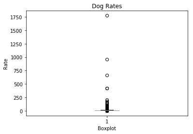

```python
plt.boxplot(archive_analyze["rating_numerator"])
plt.xlabel("Boxplot")
plt.ylabel("Rate")
plt.title("Dog Rates")
plt.savefig("boxplot.png")
```

```python
archive_analyze.describe()
```

|  | rating_numerator | rating_denominator | retweet_count | favorite_count |
| --- | --- | --- | --- | --- |
| count | 2175.000000 | 2175.000000 | 2175.000000 | 2175.000000 |
| mean | 13.221149 | 10.492874 | 2724.261609 | 8732.824368 |
| std | 47.725112 | 7.019084 | 4686.940457 | 12430.526513 |
| min | 0.000000 | 0.000000 | 0.000000 | 51.000000 |
| 25% | 10.000000 | 10.000000 | 593.000000 | 1875.500000 |
| 50% | 11.000000 | 10.000000 | 1311.000000 | 3967.000000 |
| 75% | 12.000000 | 10.000000 | 3136.000000 | 10925.500000 |
| max | 1776.000000 | 170.000000 | 77746.000000 | 143985.000000 |

There are some very big outliers. Funny how they rate dogs.

How does the tweet count of this WeRateDogs site change over time? Let's see.

```python
#remove days from timestamp
tweet_date_by_year_and_month = archive_analyze["timestamp"].apply(lambda x:x.strftime('%Y/%m'))
```

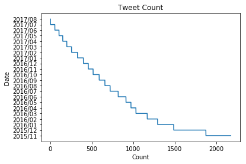

```python
#Plot year/month tweet count
plt.plot((tweet_date_by_year_and_month))
plt.xlabel('Count')
plt.ylabel('Date')
plt.savefig('tweet_count.png')
plt.title("Tweet Count")
plt.show()
```

Tweet count is decreasing. What about tweet likes? Is it decreasing too? Maybe the audience is not falling as tweet count does.

```python
# Set index to timestampt_by_months
archive_analyze.set_index("timestamp", inplace = True)
```

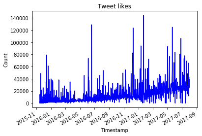

```python
archive_analyze["favorite_count"].plot(color = "blue")
plt.xlabel('Timestamp')
plt.ylabel('Count')
plt.savefig('tweet_likes.png')
plt.title('Tweet likes')
plt.show()
```

Like count is growing, se people send less pictures to the tweet site, but the audience is growing.

What about retweets?

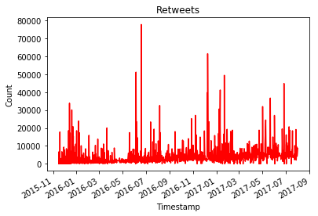

```python
archive_analyze["retweet_count"].plot(color = "red")
plt.xlabel('Timestamp')
plt.ylabel('Count')
plt.savefig('retweets.png')
plt.title('Retweets')
plt.show()
```

What is the proportion of the dogs in the tweets calculated from the first prediction?

```python
image_prediction_analyze.is_prediction_1_dog = image_prediction_analyze.is_prediction_1_dog.astype("category")
```

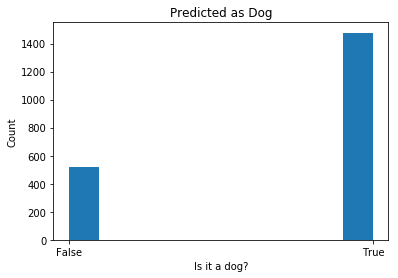

```python
plt.hist(image_prediction_analyze.is_prediction_1_dog, histtype = "barstacked")
plt.savefig("is_prediction_dog.png")
plt.title('Predicted as Dog')
plt.xlabel('Is it a dog?')
plt.ylabel('Count')
plt.show()
```

Around 75% of the pictures are predicted as dogs. This is strange, because this is supposed to be a dog rater tweet site.

## Sources

https://stackoverflow.com/

https://pandas.pydata.org/

https://matplotlib.org/

https://eu.udacity.com/